# Script Digital Marketing

Alberto Filosa

17/8/2020

# Reading Files

## Dataset 1

`raw_1_cli_fid.csv` contains info on the fidelty subscriptions of each costumer account:

- `ID_CLI`: identify client (*Foreign Key*);
- `ID_FID`: identify fidelty program (**Key**);
- `ID_NEG`: identify reference stoe;
- `TYP_CLI_FID`: identify the main account (Binomyal);
- `COD_FID`: identify the fidelty program;
- `STATUS_FID`: identify if an account is active (Binomyal);
- `DT_ACTIVE`: identify the date of activation.

```r
#-- Changed name `df_1_cli_fid` in fidelity
fidelity <- read_csv2(file.path(data_dir, "raw_1_cli_fid.csv"), #-- Directory
                          na = c("NA", ""))                     #-- Identify Missing Values

knitr::kable(head(fidelity))    #-- First 5 rows
```

| ID_CLI | ID_FID | ID_NEG | TYP_CLI_FID | COD_FID | STATUS_FID | DT_ACTIVE |
| --- | --- | --- | --- | --- | --- | --- |
| 500 | 814583 | 32 | 1 | PREMIUM | 1 | 2019-02-23 |
| 16647 | 781106 | 44 | 1 | PREMIUM | 1 | 2019-02-02 |
| 835335 | 816369 | 28 | 1 | PREMIUM | 1 | 2019-02-23 |
| 9557 | 746573 | 9 | 1 | PREMIUM | 1 | 2019-01-11 |
| 767877 | 741522 | 41 | 1 | PREMIUM | 1 | 2019-01-07 |
| 743090 | 776971 | 2 | 1 | PREMIUM | 1 | 2019-01-30 |

```r
knitr::kable(summary(fidelity)) #-- Descriptive Analysis
```

|  | ID_CLI | ID_FID | ID_NEG | TYP_CLI_FID | COD_FID | STATUS_FID | DT_ACTIVE |
| --- | --- | --- | --- | --- | --- | --- | --- |
|  | Min. : 1 | Min. : 3 | Min. : 1.0 | Min. :0.0000 | Length:370135 | Min. :0.00 | Min. :2018-01-01 |
|  | 1st Qu.:230659 | 1st Qu.:229067 | 1st Qu.: 6.0 | 1st Qu.:1.0000 | Class :character | 1st Qu.:1.00 | 1st Qu.:2018-04-15 |
|  | Median :462034 | Median :458969 | Median :23.0 | Median :1.0000 | Mode :character | Median :1.00 | Median :2018-08-10 |
|  | Mean :462486 | Mean :459425 | Mean :22.1 | Mean :0.9848 | NA | Mean :0.99 | Mean :2018-08-14 |
|  | 3rd Qu.:693200 | 3rd Qu.:688435 | 3rd Qu.:36.0 | 3rd Qu.:1.0000 | NA | 3rd Qu.:1.00 | 3rd Qu.:2018-11-30 |
|  | Max. :934919 | Max. :928121 | Max. :49.0 | Max. :1.0000 | NA | Max. :1.00 | Max. :2019-05-11 |

## Dataset 2

`raw_2_cli_account.csv` contains info on each customer account:

- `ID_CLI`: identify the client (**Key**);
- `EMAIL_PROVIDER`: identify the email account provider;
- `W_PHONE`: identify if a phone number is added (Binomyal);
- `ID_ADDRESS`: identify the address (*Foreign Key*);
- `TYP_CLI_ACCOUNT`: identify the account type of the client;
- `TYP_JOB`: identify the client job.

```r
#-- Changed name `df_2_cli_account` in account
account <- read_csv2(file.path(data_dir, "raw_2_cli_account.csv"), #-- Directory
                              na = c("NA", ""))                    #-- Identify Missing Values

knitr::kable(head(account))    #-- First 5 rows
```

| ID_CLI | EMAIL_PROVIDER | W_PHONE | ID_ADDRESS | TYP_CLI_ACCOUNT | TYP_JOB |
| --- | --- | --- | --- | --- | --- |
| 600125 | libero.it | NA | 584621 | 4 | NA |
| 729642 | gmail.com | NA | 714144 | 4 | NA |
| 304639 | yahoo.it | 1 | 284176 | 4 | NA |
| 292497 | libero.it | 1 | 272563 | 4 | NA |
| 589492 | gmail.com | NA | 573304 | 2 | NA |
| 638815 | oulook.it | 1 | 622947 | 2 | NA |

```r
knitr::kable(summary(account)) #-- Descriptive Analysis
```

|  | ID_CLI | EMAIL_PROVIDER | W_PHONE | ID_ADDRESS | TYP_CLI_ACCOUNT | TYP_JOB |
| --- | --- | --- | --- | --- | --- | --- |
|  | Min. : 1 | Length:369472 | Min. :1 | Min. : 1 | Min. :2.000 | Length:369472 |
|  | 1st Qu.:230783 | Class :character | 1st Qu.:1 | 1st Qu.:227903 | 1st Qu.:4.000 | Class :character |
|  | Median :462063 | Mode :character | Median :1 | Median :456720 | Median :4.000 | Mode :character |
|  | Mean :462541 | NA | Mean :1 | Mean :457283 | Mean :3.806 | NA |
|  | 3rd Qu.:693197 | NA | 3rd Qu.:1 | 3rd Qu.:686533 | 3rd Qu.:4.000 | NA |
|  | Max. :934919 | NA | Max. :1 | Max. :900091 | Max. :4.000 | NA |
|  | NA | NA | NA’s :27305 | NA | NA | NA |

## Dataset 3

`raw_3_cli_address.csv` contains information on the address corresponding to a customer account:

- `ID_ADDRESS`: identify the address (**Key**);
- `CAP`: identify the postal code;
- `PRV`: identify the province;
- `REGION`: identify the region.

```r
#-- Changed name `df_3_cli_address` in address
address <- read_csv2(file.path(data_dir, "raw_3_cli_address.csv"), #-- Directory
                              na = c(""))                          #-- Identify Missing Values

knitr::kable(head(address))    #-- First 5 rows
```

| ID_ADDRESS | CAP | PRV | REGION |
| --- | --- | --- | --- |
| 1337 | 20083 | MI | LOMBARDIA |
| 1344 | 20024 | MI | LOMBARDIA |
| 1347 | 20090 | MI | LOMBARDIA |
| 1347 | 20090 | MI | LOMBARDIA |
| 1347 | 20090 | MI | LOMBARDIA |
| 1347 | 20090 | MI | LOMBARDIA |

```r
knitr::kable(summary(address)) #-- Descriptive Analysis
```

|  | ID_ADDRESS | CAP | PRV | REGION |
| --- | --- | --- | --- | --- |
|  | Min. : 1 | Length:1211332 | Length:1211332 | Length:1211332 |
|  | 1st Qu.:221063 | Class :character | Class :character | Class :character |
|  | Median :437083 | Mode :character | Mode :character | Mode :character |
|  | Mean :443391 | NA | NA | NA |
|  | 3rd Qu.:664931 | NA | NA | NA |
|  | Max. :900090 | NA | NA | NA |

## Dataset 4

`raw_4_cli_privacy.csv` contains information on the privacy policies accepted by each customer:

- `ID_CLI`: identify the client (*Foreign Key*);
- `FLAG_PRIVACY_1`: identify the flag privacy (binomyal);
- `FLAG_PRIVACY_2`: identify the flag profiling (*Foreign Key*);
- `FLAG_DIRECT_MKT`: identify the flag direct marketing (binomyal).

```r
#-- Changed name `df_4_cli_privacy` in privacy
privacy <- read_csv2(file.path(data_dir, "raw_4_cli_privacy.csv"), #-- Directory
                              na = c("NA", ""))                    #-- Identify Missing Values

knitr::kable(head(privacy))    #-- First 5 rows
```

| ID_CLI | FLAG_PRIVACY_1 | FLAG_PRIVACY_2 | FLAG_DIRECT_MKT |
| --- | --- | --- | --- |
| 4691 | 1 | 1 | 1 |
| 3434 | 0 | 1 | 0 |
| 3533 | 1 | 1 | 1 |
| 9866 | 1 | 1 | 1 |
| 5799 | 1 | 1 | 1 |
| 4660 | 0 | 1 | 0 |

```r
knitr::kable(summary(privacy)) #-- Descriptive Analysis
```

|  | ID_CLI | FLAG_PRIVACY_1 | FLAG_PRIVACY_2 | FLAG_DIRECT_MKT |
| --- | --- | --- | --- | --- |
|  | Min. : 1 | Min. :0.0000 | Min. :0.0000 | Min. :0.0000 |
|  | 1st Qu.:230783 | 1st Qu.:0.0000 | 1st Qu.:1.0000 | 1st Qu.:0.0000 |
|  | Median :462063 | Median :1.0000 | Median :1.0000 | Median :1.0000 |
|  | Mean :462541 | Mean :0.6557 | Mean :0.9356 | Mean :0.6707 |
|  | 3rd Qu.:693197 | 3rd Qu.:1.0000 | 3rd Qu.:1.0000 | 3rd Qu.:1.0000 |
|  | Max. :934919 | Max. :1.0000 | Max. :1.0000 | Max. :1.0000 |

## Dataset 5

`raw_5_camp_cat.csv` contains the categorization of the marketing email communications:

- `ID_CAMP`: identify the email campaign (**Key**);
- `TYP_CAMP`: identify the type email campaign.

```r
#-- Changed name `df_5_camp_cat` in campaign_category
campaign_category <- read_csv2(file.path(data_dir, "raw_5_camp_cat.csv"), #-- Directory
                           na = c("NA", ""))                              #-- Identify Missing Values

knitr::kable(head(campaign_category))    #-- First 5 rows
```

| ID_CAMP | TYP_CAMP | CHANNEL_CAMP |
| --- | --- | --- |
| 757 | PERSONALIZED | EMAIL |
| 759 | PERSONALIZED | EMAIL |
| 760 | PERSONALIZED | EMAIL |
| 761 | PERSONALIZED | EMAIL |
| 762 | PERSONALIZED | EMAIL |
| 763 | PERSONALIZED | EMAIL |

```r
knitr::kable(summary(campaign_category)) #-- Descriptive Analysis
```

|  | ID_CAMP | TYP_CAMP | CHANNEL_CAMP |
| --- | --- | --- | --- |
|  | Min. : 5.0 | Length:848 | Length:848 |
|  | 1st Qu.: 327.8 | Class :character | Class :character |
|  | Median : 561.5 | Mode :character | Mode :character |
|  | Mean : 559.6 | NA | NA |
|  | 3rd Qu.: 812.2 | NA | NA |
|  | Max. :1052.0 | NA | NA |

## Dataset 6

`raw_6_camp_event.csv` contains the events (sents, opens and clicks) related to the marketing email communications:

- `ID_EVENT`: identify the feedback event (**Key**);
- `ID_CLI`: identify the client (*Foreign Key*);
- `ID_CAMP`: identify the email campaign (*Foreign Key*);
- `ID_DELIVERY`: identify the delivery;
- `TYP_EVENT`: identify the feedback event:
  - S = Send;
  - V = Open;
  - C = Click;
  - B = Bounce;
  - E = Error;
- `EVENT_DATE`: identify the datetime event.

```r
#-- Changed name `df_6_camp_event` in campaign_event
campaign_event <- read_csv2(file.path(data_dir, "raw_6_camp_event.csv"), #-- Directory
                             na = c("NA", ""))                           #-- Identify Missing Values

knitr::kable(head(campaign_event))    #-- First 5 rows
```

| ID_EVENT | ID_CLI | ID_CAMP | ID_DELIVERY | TYP_EVENT | EVENT_DATE |
| --- | --- | --- | --- | --- | --- |
| 11548588 | 411925 | 948 | 8996 | V | 2019-01-01 01:42:24 |
| 11548640 | 313259 | 949 | 8997 | V | 2019-01-01 02:54:04 |
| 11548572 | 327299 | 941 | 8817 | V | 2019-01-01 01:23:29 |
| 11548515 | 627427 | 923 | 8263 | V | 2019-01-01 00:43:06 |
| 11548609 | 265258 | 950 | 8998 | V | 2019-01-01 02:11:03 |
| 11548497 | 693938 | 955 | 9115 | V | 2019-01-01 00:29:04 |

```r
knitr::kable(summary(campaign_event)) #-- Descriptive Analysis
```

|  | ID_EVENT | ID_CLI | ID_CAMP | ID_DELIVERY | TYP_EVENT | EVENT_DATE |
| --- | --- | --- | --- | --- | --- | --- |
|  | Min. :11548441 | Min. : 1 | Min. : 148.0 | Min. : 7680 | Length:2060360 | Min. :2019-01-01 00:00:46 |
|  | 1st Qu.:13526812 | 1st Qu.:208129 | 1st Qu.: 970.0 | 1st Qu.:10066 | Class :character | 1st Qu.:2019-02-13 13:01:06 |
|  | Median :14867410 | Median :398084 | Median : 991.0 | Median :10585 | Mode :character | Median :2019-02-28 14:01:27 |
|  | Mean :14757544 | Mean :413793 | Mean : 928.9 | Mean :10534 | NA | Mean :2019-03-04 14:23:02 |
|  | 3rd Qu.:16284762 | 3rd Qu.:618440 | 3rd Qu.:1024.0 | 3rd Qu.:11151 | NA | 3rd Qu.:2019-04-04 17:52:18 |
|  | Max. :17650340 | Max. :931973 | Max. :1048.0 | Max. :11509 | NA | Max. :2019-04-30 23:58:41 |

## Dataset 7

`raw_7_tic.csv` contains the purchase and refund transaction of each customer:

- `ID_SCONTRINO`: identify the transaction (all products have same ID);
- `ID_CLI`: identify the client (*Foreign Key*);
- `ID_NEG`: identify the reference store (*Foreign Key*);
- `ID_ARTICOLO`: identify the purchased or refund item;
- `COD_REPARTO`: identify the business unit corresponding to the item;
- `DIREZIONE`: identify the purchase (1) or refund (-1);
- `IMPORTO_LORDO`: identify the gross amount as the sum of net amount and the discount applied;
- `SCONTO`: identify the discount applied (negative if refund);
- `DATETIME`: datetime of the transaction.

```r
#-- Changed name `df_7_tic` in tickets
tickets <- read_csv2(file.path(data_dir, "raw_7_tic.csv"), #-- Directory
                      na = c("NA", ""))                    #-- Identify Missing Values

knitr::kable(head(tickets))    #-- First 5 rows
```

| ID_SCONTRINO | ID_CLI | ID_NEG | ID_ARTICOLO | COD_REPARTO | DIREZIONE | IMPORTO_LORDO | SCONTO | DATETIME |
| --- | --- | --- | --- | --- | --- | --- | --- | --- |
| 51299709701/05/18718488513770 | 318714 | 48 | 34216854 | 2 | 1 | 22.80 | 0.05 | 2018-05-01 07:18:48 |
| 51299709701/05/18718488513770 | 318714 | 48 | 34216854 | 2 | 1 | 22.75 | 0.00 | 2018-05-01 07:18:48 |
| 51399406901/05/18718488528430 | 324419 | 47 | 36167733 | 9 | 1 | 1290.00 | 491.00 | 2018-05-01 07:18:48 |
| 511499219301/05/18718488544998 | 332611 | 36 | 32404540 | 13 | 1 | 134.00 | 34.10 | 2018-05-01 07:18:48 |
| 511599623601/05/18718498530796 | 325589 | 35 | 35811412 | 9 | 1 | 399.00 | 0.00 | 2018-05-01 07:18:49 |
| 511599623601/05/18718498530796 | 325589 | 35 | 35811741 | 9 | 1 | 474.00 | 0.00 | 2018-05-01 07:18:49 |

```r
knitr::kable(summary(tickets)) #-- Descriptive Analysis
```

|  | ID_SCONTRINO | ID_CLI | ID_NEG | ID_ARTICOLO | COD_REPARTO | DIREZIONE | IMPORTO_LORDO | SCONTO | DATETIME |
| --- | --- | --- | --- | --- | --- | --- | --- | --- | --- |
|  | Length:4263220 | Min. : 5 | Min. : 2.00 | Min. : 16921 | Min. : 1.000 | Min. :-1.0000 | Min. :-17465.00 | Min. :-2472.000 | Min. :2018-05-01 07:18:48 |
|  | Class :character | 1st Qu.:211201 | 1st Qu.:14.00 | 1st Qu.:34141800 | 1st Qu.: 3.000 | 1st Qu.: 1.0000 | 1st Qu.: 2.67 | 1st Qu.: 0.000 | 1st Qu.:2018-08-12 14:05:04 |
|  | Mode :character | Median :411821 | Median :27.00 | Median :35558446 | Median : 7.000 | Median : 1.0000 | Median : 7.50 | Median : 0.000 | Median :2018-11-09 16:37:45 |
|  | NA | Mean :411433 | Mean :25.93 | Mean :38022591 | Mean : 7.393 | Mean : 0.8866 | Mean : 32.65 | Mean : 2.329 | Mean :2018-11-06 03:52:05 |
|  | NA | 3rd Qu.:601672 | 3rd Qu.:38.00 | 3rd Qu.:36144465 | 3rd Qu.:11.000 | 3rd Qu.: 1.0000 | 3rd Qu.: 22.00 | 3rd Qu.: 0.000 | 3rd Qu.:2019-02-02 12:49:36 |
|  | NA | Max. :934729 | Max. :49.00 | Max. :82231481 | Max. :14.000 | Max. : 1.0000 | Max. : 17465.00 | Max. : 4853.590 | Max. :2019-04-30 21:57:25 |

# Cleaning Files

First of all, it is reccomended to create a copy for all datasets before data manipulation:

```r
fidelity_clean <- fidelity          #-- Dataset 1
account_clean  <- account           #-- Dataset 2
address_clean  <- address           #-- Dataset 3
privacy_clean  <- privacy           #-- Dataset 4
campaign_category_clean <- campaign_category #-- Dataset 5
campaign_event_clean    <- campaign_event    #-- Dataset 6
tickets_clean  <- tickets           #-- Dataset 7
```

## 1. Fidelity

First, we check if there are some duplicate rows:

```r
fidelity_clean_duplicate <- fidelity_clean %>%
                              summarize(TOT_ID_CLIs = n_distinct(ID_CLI), #-- Number of Total Clients
                              TOT_ID_FIDs = n_distinct(ID_FID),           #-- Number of Total Fidelity Program
                              TOT_ID_CLIFIDs = n_distinct(paste0(as.character(ID_CLI), "-",
                                                                 as.character(ID_FID))),
                              TOT_ROWs = n())                             #-- Number of Total Rows

knitr::kable(fidelity_clean_duplicate)
```

| TOT_ID_CLIs | TOT_ID_FIDs | TOT_ID_CLIFIDs | TOT_ROWs |
| --- | --- | --- | --- |
| 369472 | 367925 | 370135 | 370135 |

```r
fidelity_clean <- fidelity_clean                                 %>%
                    mutate(DT_ACTIVE = as.Date(DT_ACTIVE))       %>% #-- Formatting dates
                    mutate(TYP_CLI_FID = as.factor(TYP_CLI_FID)) %>% #-- Factorize TYP_CLI_FID
                    mutate(STATUS_FID = as.factor(STATUS_FID))       #-- Factorize STATUS_FID
```

Check the number of fidelity subscriptions per client:

```r
num_fid_x_cli <- fidelity_clean     %>%
                   group_by(ID_CLI) %>%                         #-- Group by Client
                   summarize(NUM_FIDs  = n_distinct(ID_FID),    #-- Distinct Fidelity
                             NUM_DATEs = n_distinct(DT_ACTIVE)) #-- Distinct Date

tot_id_cli <- n_distinct(num_fid_x_cli$ID_CLI)

dist_num_fid_x_cli <- num_fid_x_cli %>%
                        group_by(NUM_FIDs, NUM_DATEs)            %>% #-- Group by Client and Date of Activation
                        summarize(TOT_CLIs = n_distinct(ID_CLI)) %>% #-- Total Clients
                        mutate(PERCENT_CLIs = TOT_CLIs/tot_id_cli)   #-- Percentage

knitr::kable(dist_num_fid_x_cli)
```

| NUM_FIDs | NUM_DATEs | TOT_CLIs | PERCENT_CLIs |
| --- | --- | --- | --- |
| 1 | 1 | 368833 | 0.9982705 |
| 2 | 1 | 254 | 0.0006875 |
| 2 | 2 | 363 | 0.0009825 |
| 3 | 1 | 7 | 0.0000189 |
| 3 | 2 | 8 | 0.0000217 |
| 3 | 3 | 5 | 0.0000135 |
| 4 | 1 | 2 | 0.0000054 |

Note that there are clients with multiple fidelity subscriptions. In details, let examine clients with multiple subscriptions:

```r
num_fid_x_cli %>%
  filter(NUM_FIDs == 3)
```

```
## # A tibble: 20 x 3
##    ID_CLI NUM_FIDs NUM_DATEs
##     <dbl>    <int>     <int>
##  1   7533        3         3
##  2  11477        3         1
##  3  68556        3         1
##  4  96537        3         1
##  5 223203        3         3
##  6 250133        3         2
##  7 311669        3         1
##  8 320880        3         2
##  9 621814        3         3
## 10 648813        3         3
## 11 662651        3         3
## 12 671097        3         2
## 13 688941        3         2
## 14 722274        3         2
## 15 736520        3         2
## 16 757759        3         2
## 17 792369        3         1
## 18 826640        3         2
## 19 859327        3         1
## 20 879261        3         1
```

```r
fidelity_clean %>%
  filter(ID_CLI == 621814)
```

```
## # A tibble: 3 x 7
##   ID_CLI ID_FID ID_NEG TYP_CLI_FID COD_FID  STATUS_FID DT_ACTIVE
##    <dbl>  <dbl>  <dbl> <fct>       <chr>    <fct>      <date>
## 1 621814 578123      1 1           STANDARD 0          2018-10-13
## 2 621814 646483     18 1           STANDARD 0          2018-11-13
## 3 621814 661124     18 1           STANDARD 1          2018-11-20
```

```r
fidelity_clean %>%
  filter(ID_CLI == 320880)
```

```
## # A tibble: 3 x 7
##   ID_CLI ID_FID ID_NEG TYP_CLI_FID COD_FID  STATUS_FID DT_ACTIVE
##    <dbl>  <dbl>  <dbl> <fct>       <chr>    <fct>      <date>
## 1 320880 248462      8 1           STANDARD 0          2018-04-25
## 2 320880 250899      8 1           PREMIUM  0          2018-04-26
## 3 320880 250910      8 1           STANDARD 1          2018-04-26
```

After, we combine the information for each client from first subscription (registration date and store for registration) to the last (type of fidelity and status):

```r
client_fidelity_first <- fidelity_clean                        %>%
                           group_by(ID_CLI)                    %>% #-- Grouped by Client ID
                           filter(DT_ACTIVE == min(DT_ACTIVE)) %>% #-- Filtered by min DT_ACTIVE
                           arrange(ID_FID)                     %>% #-- Sorted by client ID
                           filter(row_number() == 1)           %>% #-- Filter Row #1
                           ungroup()                           %>%
                           as.data.frame()

client_fidelity_last <- fidelity_clean                        %>%
                          group_by(ID_CLI)                    %>% #-- Grouped by Client ID
                          filter(DT_ACTIVE == max(DT_ACTIVE)) %>% #-- Filtered by max DT_ACTIVE
                          arrange(desc(ID_FID))               %>% #-- Sorted by client ID
                          filter(row_number() == 1)           %>% #-- Filter Row #1
                          ungroup()                           %>%
                          as.data.frame()
```

We left join `client_fidelity_first` and `num_fid_x_cli` in `df_1_cli_fid_last`:

```r
fidelity_clean <- client_fidelity_last                      %>%
                      select(ID_CLI,
                             ID_FID,
                             LAST_COD_FID = COD_FID,
                             LAST_TYP_CLI_FID = TYP_CLI_FID,
                             LAST_STATUS_FID = STATUS_FID,
                             LAST_DT_ACTIVE = DT_ACTIVE)    %>% #-- Selection of Variables
                      left_join(client_fidelity_first       %>% #-- Left Join with client_fidelity_first
                                  select(ID_CLI,
                                         FIRST_ID_NEG = ID_NEG,
                                         FIRST_DT_ACTIVE = DT_ACTIVE),
                                by = 'ID_CLI')              %>%
                      left_join(num_fid_x_cli         %>%       #-- Left Join with num_fid_x_cli
                                  select(ID_CLI,
                                         NUM_FIDs)          %>%
                                  mutate(NUM_FIDs = as.factor(NUM_FIDs)),
                                by = 'ID_CLI')
```

### Exploration Analysis

First, it’s necessary to compute the distribution of the fidelity program:

```r
df1_dist_codfid <- fidelity_clean          %>%
  group_by(LAST_COD_FID)                   %>% #-- Grouped by Fidelty Program
  summarize(TOT_CLIs = n_distinct(ID_CLI)) %>% #-- Number of Total Client
  mutate(PERCENT = TOT_CLIs/sum(TOT_CLIs)) %>% #-- Percent
  arrange(desc(PERCENT))                       #-- Sort by Percent decreasing

knitr::kable(df1_dist_codfid)
```

| LAST_COD_FID | TOT_CLIs | PERCENT |
| --- | --- | --- |
| STANDARD | 289756 | 0.7842435 |
| PREMIUM | 43878 | 0.1187587 |
| STANDARD BIZ | 29148 | 0.0788910 |
| PREMIUM BIZ | 6690 | 0.0181069 |

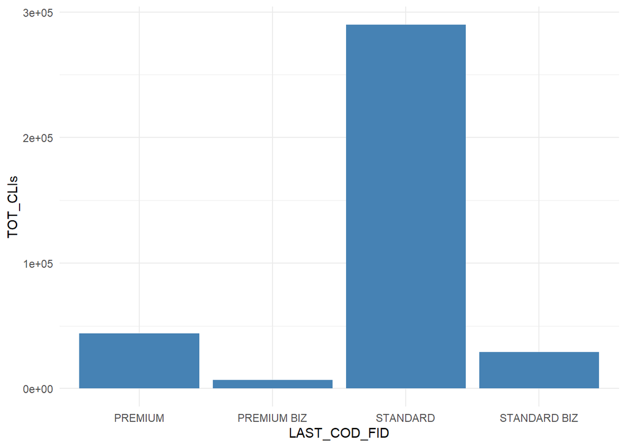

```r
ggplot(data = df1_dist_codfid,
       aes(x = LAST_COD_FID, y = TOT_CLIs)) +  #-- Dataset to Plot
  geom_bar(stat = "identity",
           fill = "steelblue") +               #-- Bar Plot
  theme_minimal()                              #-- ggplot Theme
```

Let’s explore the status variable (`LAST_STATUS_FID`):

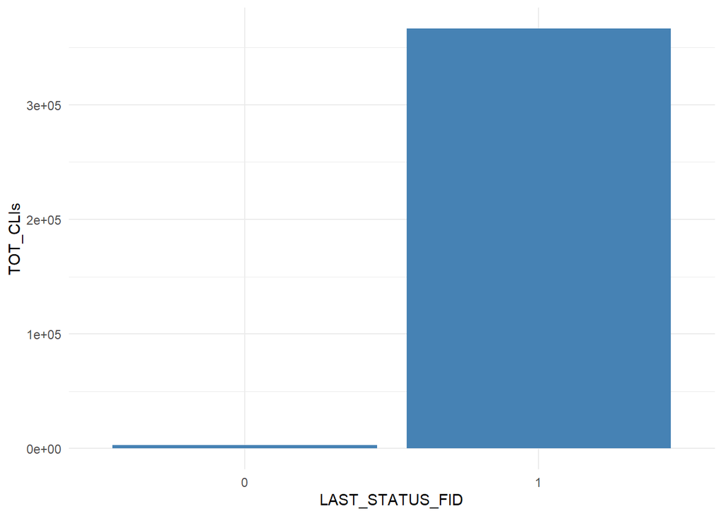

```r
df1_dist_status <- fidelity_clean          %>%
  group_by(LAST_STATUS_FID)                %>%   #-- Grouped by Active Account
  summarize(TOT_CLIs = n_distinct(ID_CLI)) %>%   #-- Number of Total Client
  mutate(PERCENT = TOT_CLIs/sum(TOT_CLIs)) %>%   #-- Percent
  arrange(desc(PERCENT))                         #-- Sort by Percent decreasing


ggplot(data = df1_dist_status,
       aes(x = LAST_STATUS_FID, y = TOT_CLIs)) + #-- Dataset to Plot
  geom_bar(stat = "identity",
           fill = "steelblue") +                 #-- Bar Plot
  theme_minimal()                                #-- ggplot Theme
```

Let’s explore the fidelity card variable (`NUM_FIDs`):

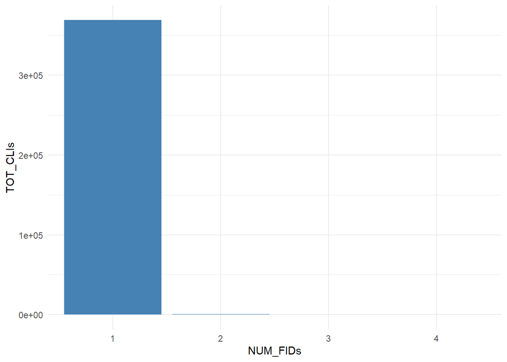

```r
df1_dist_num <- fidelity_clean             %>%
  group_by(NUM_FIDs)                       %>% #-- Grouped by Fidelity Program
  summarize(TOT_CLIs = n_distinct(ID_CLI)) %>% #-- Number of Total Client
  mutate(PERCENT = TOT_CLIs/sum(TOT_CLIs)) %>% #-- Percent
  arrange(desc(PERCENT))                       #-- Sort by Percent decreasing

ggplot(data = df1_dist_num,
       aes(x = NUM_FIDs, y = TOT_CLIs)) +      #-- Dataset to Plot
  geom_bar(stat = "identity",
           fill = "steelblue") +               #-- Bar Plot
  theme_minimal()                              #-- ggplot Theme
```

Let’s explore the last fidelity card variable (`LAST_TYP_CLI_FID`):

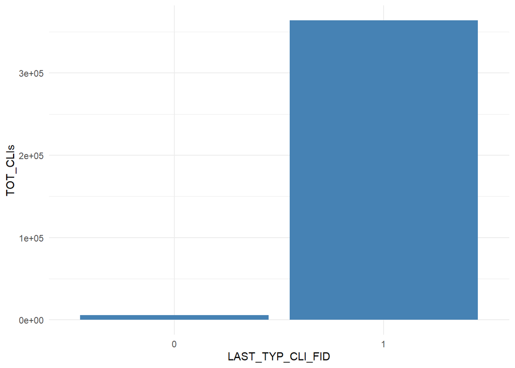

```r
df1_dist_type <- fidelity_clean            %>%
  group_by(LAST_TYP_CLI_FID)               %>%    #-- Grouped by Main Account
  summarize(TOT_CLIs = n_distinct(ID_CLI)) %>%    #-- Number of Total Client
  mutate(PERCENT = TOT_CLIs/sum(TOT_CLIs)) %>%    #-- Percent
  arrange(desc(PERCENT))                          #-- Sort by Percent decreasing

ggplot(data = df1_dist_type,
       aes(x = LAST_TYP_CLI_FID, y = TOT_CLIs)) + #-- Dataset to Plot
  geom_bar(stat = "identity",
           fill = "steelblue") +                  #-- Bar Plot
  theme_minimal()                                 #-- ggplot Theme
```

Let’s explore the date of activation card variable (`FIRST_DT_ACTIVE`):

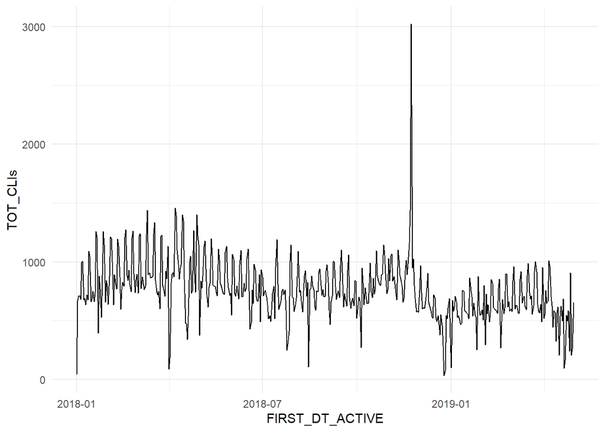

```r
df1_dist_date <- fidelity_clean            %>%
  group_by(FIRST_DT_ACTIVE)                %>%   #-- Grouped by Date of Activation
  summarize(TOT_CLIs = n_distinct(ID_CLI)) %>%   #-- Number of Total Client
  mutate(PERCENT = TOT_CLIs/sum(TOT_CLIs)) %>%   #-- Percent
  arrange(desc(PERCENT))                         #-- Sort by Percent decreasing

ggplot(data = df1_dist_date,
       aes(x = FIRST_DT_ACTIVE, y = TOT_CLIs)) + #-- Dataset to Plot
  geom_line() +                                  #-- Bar Plot
  theme_minimal()                                #-- ggplot Theme
```

## 2. Account

We check for duplicate rows:

```r
account_clean_duplicate <- account_clean %>%
                            summarize(TOT_ID_CLIs = n_distinct(ID_CLI),
                                      TOT_ROWs = n())

knitr::kable(account_clean_duplicate) #-- No Duplicated rows
```

| TOT_ID_CLIs | TOT_ROWs |
| --- | --- |
| 369472 | 369472 |

```r
account_clean <- account_clean %>%
                  mutate(W_PHONE = as.factor(W_PHONE)) %>%                 #-- Factorized
                  mutate(TYP_CLI_ACCOUNT = as.factor(TYP_CLI_ACCOUNT)) %>% #-- Factorized
                  mutate(W_PHONE = fct_explicit_na(W_PHONE, "0")) %>%      #-- Missing Values
                  mutate(EMAIL_PROVIDER = fct_explicit_na(EMAIL_PROVIDER, "(missing)")) %>% #-- NA with Categorial
                  mutate(TYP_JOB = fct_explicit_na(TYP_JOB, "(missing)"))  #-- NA with Categorial
```

### Reshaping

```r
df_2_dist_emailprovider <- account_clean %>%
                            group_by(EMAIL_PROVIDER) %>%                 #-- Group by EMAIL_PROVIDER
                            summarize(TOT_CLIs = n_distinct(ID_CLI)) %>%
                            mutate(PERCENT = TOT_CLIs/sum(TOT_CLIs)) %>%
                            arrange(desc(PERCENT)) %>%
                            as.data.frame()

knitr::kable(head(df_2_dist_emailprovider))
```

| EMAIL_PROVIDER | TOT_CLIs | PERCENT |
| --- | --- | --- |
| gmail.com | 151508 | 0.4100663 |
| libero.it | 57782 | 0.1563907 |
| hotmail.it | 28698 | 0.0776730 |
| alice.it | 18127 | 0.0490619 |
| yahoo.it | 16538 | 0.0447612 |
| hotmail.com | 10076 | 0.0272713 |

There are 20512: too many different values for `EMAIL_PROVIDER` to be an useful category. We keep the most frequent email provider values and add a common factor level `other` for the remaining:

```r
knitr::kable(df_2_dist_emailprovider %>%
  arrange(desc(PERCENT)) %>%
  mutate(PERCENT_COVERED = cumsum(TOT_CLIs)/sum(TOT_CLIs)) %>%
  as.data.frame() %>%
  head(20))
```

| EMAIL_PROVIDER | TOT_CLIs | PERCENT | PERCENT_COVERED |
| --- | --- | --- | --- |
| gmail.com | 151508 | 0.4100663 | 0.4100663 |
| libero.it | 57782 | 0.1563907 | 0.5664570 |
| hotmail.it | 28698 | 0.0776730 | 0.6441300 |
| alice.it | 18127 | 0.0490619 | 0.6931919 |
| yahoo.it | 16538 | 0.0447612 | 0.7379531 |
| hotmail.com | 10076 | 0.0272713 | 0.7652244 |
| virgilio.it | 9161 | 0.0247948 | 0.7900193 |
| tiscali.it | 8733 | 0.0236364 | 0.8136557 |
| live.it | 7936 | 0.0214793 | 0.8351350 |
| (missing) | 5889 | 0.0159390 | 0.8510740 |
| icloud.com | 3735 | 0.0101090 | 0.8611830 |
| yahoo.com | 3259 | 0.0088207 | 0.8700037 |
| gmail.it | 2266 | 0.0061331 | 0.8761368 |
| tin.it | 2183 | 0.0059084 | 0.8820452 |
| outlook.it | 2039 | 0.0055187 | 0.8875639 |
| fastwebnet.it | 1749 | 0.0047338 | 0.8922977 |
| inwind.it | 1514 | 0.0040977 | 0.8963954 |
| email.it | 1103 | 0.0029853 | 0.8993807 |
| me.com | 1034 | 0.0027986 | 0.9021793 |
| live.com | 837 | 0.0022654 | 0.9044447 |

```r
clean_email_providers <- df_2_dist_emailprovider %>%
  arrange(desc(PERCENT)) %>%
  mutate(PERCENT_COVERED = cumsum(TOT_CLIs)/sum(TOT_CLIs)) %>%
  mutate(EMAIL_PROVIDER = as.character(EMAIL_PROVIDER)) %>%
  mutate(AUX = if_else(PERCENT_COVERED < 0.85 | (PERCENT_COVERED > 0.85 & lag(PERCENT_COVERED) < 0.85), 1,0)) %>%
  mutate(EMAIL_PROVIDER_CLEAN = if_else(AUX | EMAIL_PROVIDER == "(missing)", EMAIL_PROVIDER, "others"))

knitr::kable(head(clean_email_providers, 7))
```

| EMAIL_PROVIDER | TOT_CLIs | PERCENT | PERCENT_COVERED | AUX | EMAIL_PROVIDER_CLEAN |
| --- | --- | --- | --- | --- | --- |
| gmail.com | 151508 | 0.4100663 | 0.4100663 | 1 | gmail.com |
| libero.it | 57782 | 0.1563907 | 0.5664570 | 1 | libero.it |
| hotmail.it | 28698 | 0.0776730 | 0.6441300 | 1 | hotmail.it |
| alice.it | 18127 | 0.0490619 | 0.6931919 | 1 | alice.it |
| yahoo.it | 16538 | 0.0447612 | 0.7379531 | 1 | yahoo.it |
| hotmail.com | 10076 | 0.0272713 | 0.7652244 | 1 | hotmail.com |
| virgilio.it | 9161 | 0.0247948 | 0.7900193 | 1 | virgilio.it |

```r
account_clean <- account_clean %>%
  mutate(EMAIL_PROVIDER = as.character(EMAIL_PROVIDER)) %>%
  left_join(clean_email_providers %>%
              select(EMAIL_PROVIDER, EMAIL_PROVIDER_CLEAN),
            by = "EMAIL_PROVIDER") %>%
  select(-EMAIL_PROVIDER) %>%
  mutate(EMAIL_PROVIDER_CLEAN = as.factor(EMAIL_PROVIDER_CLEAN))
```

```r
df_2_dist_phone <- account_clean %>%
  group_by(W_PHONE) %>%
  summarize(TOT_CLIs = n_distinct(ID_CLI)) %>%
  mutate(PERCENT = TOT_CLIs/sum(TOT_CLIs)) %>%
  arrange(desc(PERCENT)) %>%
  as.data.frame()

knitr::kable(df_2_dist_phone)
```

| W_PHONE | TOT_CLIs | PERCENT |
| --- | --- | --- |
| 1 | 342167 | 0.9260972 |
| 0 | 27305 | 0.0739028 |

```r
df_2_dist_account <- account_clean %>%
  group_by(TYP_CLI_ACCOUNT) %>%
  summarize(TOT_CLIs = n_distinct(ID_CLI)) %>%
  mutate(PERCENT = TOT_CLIs/sum(TOT_CLIs)) %>%
  arrange(desc(PERCENT)) %>%
  as.data.frame()

knitr::kable(df_2_dist_account)
```

| TYP_CLI_ACCOUNT | TOT_CLIs | PERCENT |
| --- | --- | --- |
| 4 | 333656 | 0.9030617 |
| 2 | 35816 | 0.0969383 |

### Exploration Analysis

Let’s explore the email provider for each client (`EMAIL_PROVIDER_CLEAN`):

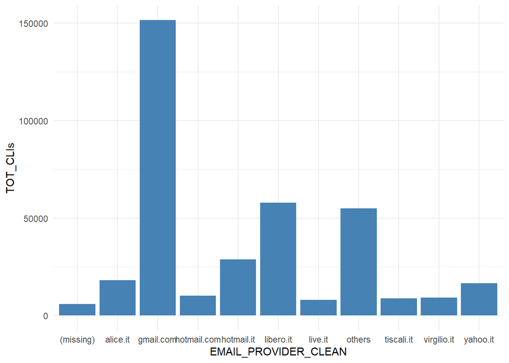

```r
df2_dist_emailproviderclean <- account_clean %>%
  group_by(EMAIL_PROVIDER_CLEAN) %>%
  summarize(TOT_CLIs = n_distinct(ID_CLI)) %>%
  mutate(PERCENT = TOT_CLIs/sum(TOT_CLIs)) %>%
  arrange(desc(PERCENT))

ggplot(data = df2_dist_emailproviderclean,
       aes(x = EMAIL_PROVIDER_CLEAN,
           y = TOT_CLIs)) +
  geom_bar(stat = "identity",
           fill = "steelblue") +
  theme_minimal()
```

Let’s explore the type job for each client (`TYP_JOB`):

```r
df_2_dist_job <- account_clean %>%
  group_by(TYP_JOB) %>%
  summarize(TOT_CLIs = n_distinct(ID_CLI)) %>%
  mutate(PERCENT = TOT_CLIs/sum(TOT_CLIs)) %>%
  arrange(desc(PERCENT)) %>%
  as.data.frame()

knitr::kable(df_2_dist_job)
```

| TYP_JOB | TOT_CLIs | PERCENT |
| --- | --- | --- |
| (missing) | 360810 | 0.9765557 |
| Libero professionista | 3970 | 0.0107451 |
| Impiegato/a | 1560 | 0.0042222 |
| Altro | 784 | 0.0021219 |
| Pensionato/a | 641 | 0.0017349 |
| Operaio/a | 482 | 0.0013046 |
| Dirigente/Quadro/Funzionario | 354 | 0.0009581 |
| Non Dichiara | 218 | 0.0005900 |
| Casalinga | 191 | 0.0005170 |
| Artigiano | 131 | 0.0003546 |
| Imprenditore | 108 | 0.0002923 |
| In cerca di occupazione | 79 | 0.0002138 |
| Commerciante/Esercente | 71 | 0.0001922 |
| Studente | 54 | 0.0001462 |
| Rappresentante/Agente Commerciale | 19 | 0.0000514 |

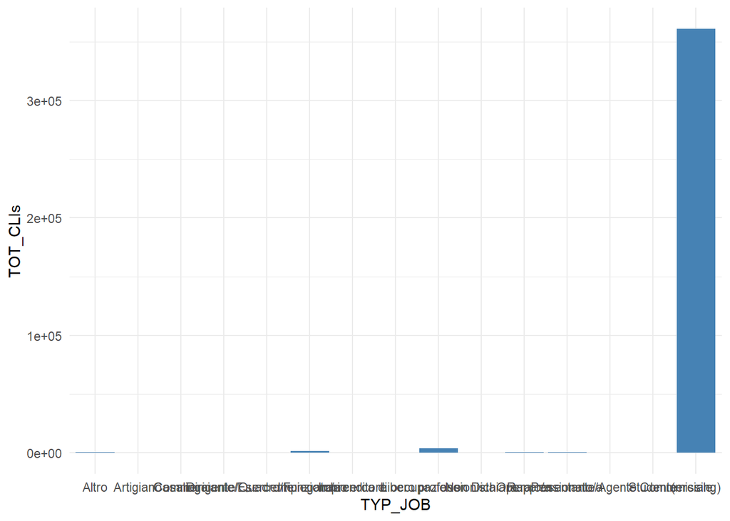

```r
ggplot(data = df_2_dist_job,
       aes(x = TYP_JOB,
           y = TOT_CLIs)) +
  geom_bar(stat = "identity",
           fill = "steelblue") +
  theme_minimal()
```

Let’s explore the type account for each client (`TYP_CLI_ACCOUNT`):

```r
df_2_dist_account <- account_clean %>%
  group_by(TYP_CLI_ACCOUNT) %>%
  summarize(TOT_CLIs = n_distinct(ID_CLI)) %>%
  mutate(PERCENT = TOT_CLIs/sum(TOT_CLIs)) %>%
  arrange(desc(PERCENT)) %>%
  as.data.frame()

knitr::kable(df_2_dist_account)
```

| TYP_CLI_ACCOUNT | TOT_CLIs | PERCENT |
| --- | --- | --- |
| 4 | 333656 | 0.9030617 |
| 2 | 35816 | 0.0969383 |

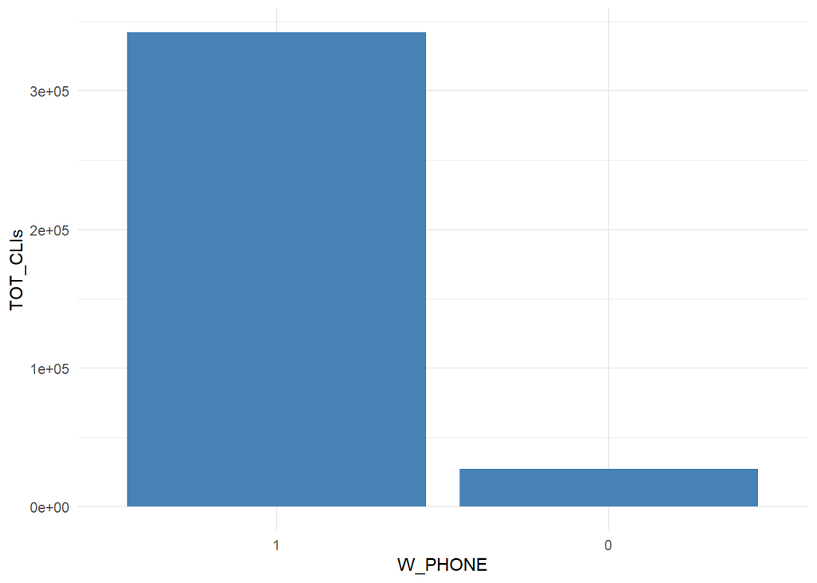

```r
ggplot(data = df_2_dist_phone,
       aes(x = W_PHONE,
           y = TOT_CLIs)) +
  geom_bar(stat = "identity",
           fill = "steelblue") +
  theme_minimal()
```

## 3. Address

We check for duplicate rows:

```r
knitr::kable(address_clean %>%
               summarize(TOT_ID_ADDRESSes = n_distinct(ID_ADDRESS),
               TOT_ROWs = n()))
```

| TOT_ID_ADDRESSes | TOT_ROWs |
| --- | --- |
| 361330 | 1211332 |

```r
#-- Remove Duplicates
address_clean <- address_clean %>%
                  distinct()
```

Let’s manipulate missing values:

```r
address_clean <- address_clean %>%
                    mutate(CAP = as.character(CAP)) %>% #-- Factorized
                    filter(!is.na(CAP) & !is.na(PRV) & !is.na(REGION))
```

### Explanatory Analysis

Let’s explore the CAP address (`CAP`):

```r
nrow(address_clean %>%
  distinct(CAP))
```

```
## [1] 4784
```

There are 4784: too many to plot.

Let’s explore the province address (`PRV`):

```r
nrow(address_clean %>%
  distinct(PRV))
```

```
## [1] 110
```

There are 110: too many to plot.

Let’s explore the region for each client (`REGION`):

```r
df3_dist_region<- address_clean %>%
  group_by(REGION) %>%
  summarize(TOT_ADDRESS = n_distinct(ID_ADDRESS)) %>%
  mutate(PERCENT = TOT_ADDRESS/sum(TOT_ADDRESS)) %>%
  arrange(desc(PERCENT))

knitr::kable(head(df3_dist_region))
```

| REGION | TOT_ADDRESS | PERCENT |
| --- | --- | --- |
| LOMBARDIA | 97181 | 0.2879710 |
| LAZIO | 32058 | 0.0949957 |
| CAMPANIA | 30570 | 0.0905864 |
| VENETO | 29696 | 0.0879965 |
| SICILIA | 28329 | 0.0839457 |
| PIEMONTE | 24377 | 0.0722350 |

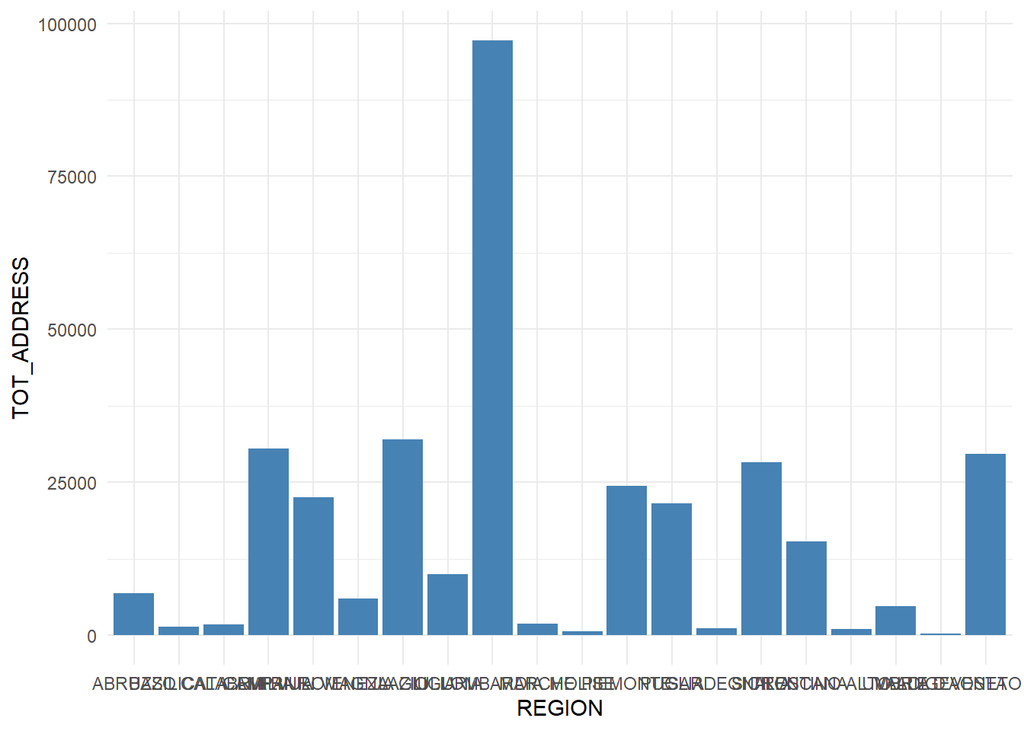

```r
ggplot(data = df3_dist_region, aes(x = REGION,
                                   y = TOT_ADDRESS)) +
  geom_bar(stat = "identity",
           fill = "steelblue") +
  theme_minimal()
```

## 4. Privacy

We check for duplicate rows:

```r
knitr::kable(privacy_clean %>%
               summarize(TOT_ID_CLIs = n_distinct(ID_CLI),
               TOT_ROWs = n())) #-- No Duplicated rows
```

| TOT_ID_CLIs | TOT_ROWs |
| --- | --- |
| 369472 | 369472 |

Let’s manipulate the privacy dataset:

```r
privacy_clean <- privacy_clean %>%
  mutate(FLAG_PRIVACY_1 = as.factor(FLAG_PRIVACY_1)) %>% #-- Factorized
  mutate(FLAG_PRIVACY_2 = as.factor(FLAG_PRIVACY_2)) %>% #-- Factorized
  mutate(FLAG_DIRECT_MKT = as.factor(FLAG_DIRECT_MKT))   #-- Factorized
```

### Explanatory Analysis

Let’s explore the first privacy method (FLAG_PRIVACY_1):

```r
df4_dist_privacy1<- privacy_clean %>%
                      group_by(FLAG_PRIVACY_1) %>%
                      summarize(TOT_ID = n_distinct(ID_CLI)) %>%
                      mutate(PERCENT = TOT_ID/sum(TOT_ID)) %>%
                      arrange(desc(PERCENT))

knitr::kable(df4_dist_privacy1)
```

| FLAG_PRIVACY_1 | TOT_ID | PERCENT |
| --- | --- | --- |
| 1 | 242251 | 0.6556681 |
| 0 | 127221 | 0.3443319 |

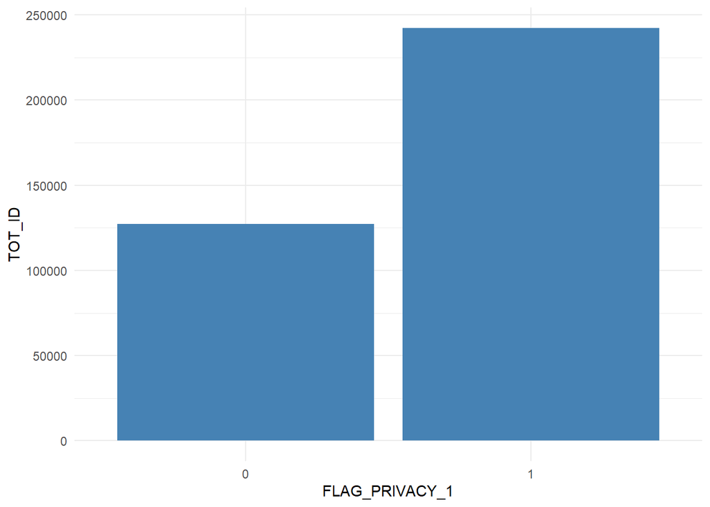

```r
ggplot(data = df4_dist_privacy1,
       aes(x = FLAG_PRIVACY_1,
           y = TOT_ID)) +
  geom_bar(stat = "identity",
           fill = "steelblue") +
  theme_minimal()
```

Let’s explore the second privacy method (FLAG_PRIVACY_2):

```r
df4_dist_privacy2<- privacy_clean %>%
                      group_by(FLAG_PRIVACY_2) %>%
                      summarize(TOT_ID = n_distinct(ID_CLI)) %>%
                      mutate(PERCENT = TOT_ID/sum(TOT_ID)) %>%
                      arrange(desc(PERCENT))

knitr::kable(df4_dist_privacy2)
```

| FLAG_PRIVACY_2 | TOT_ID | PERCENT |
| --- | --- | --- |
| 1 | 345682 | 0.9356108 |
| 0 | 23790 | 0.0643892 |

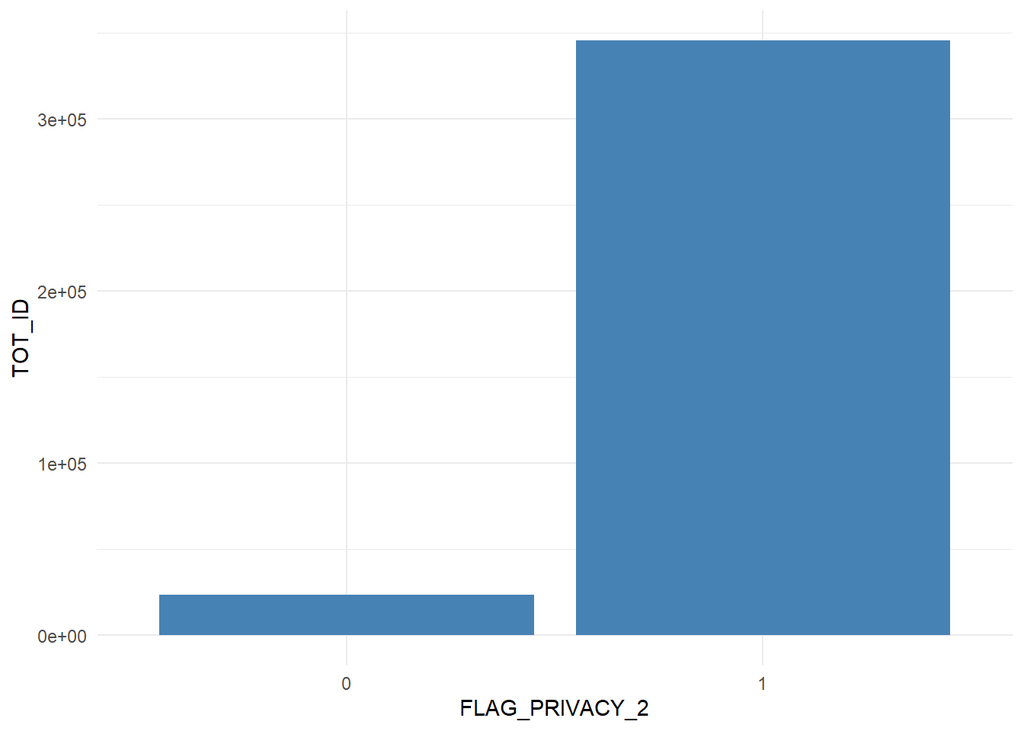

```r
ggplot(data = df4_dist_privacy2,
       aes(x = FLAG_PRIVACY_2,
           y = TOT_ID)) +
  geom_bar(stat = "identity",
           fill = "steelblue") +
  theme_minimal()
```

Let’s explore the privacy MTK method (FLAG_DIRECT_MKT):

```r
df4_dist_privacy_mkt<- privacy_clean %>%
                          group_by(FLAG_DIRECT_MKT) %>%
                          summarize(TOT_ID = n_distinct(ID_CLI)) %>%
                          mutate(PERCENT = TOT_ID/sum(TOT_ID)) %>%
                          arrange(desc(PERCENT))

knitr::kable(df4_dist_privacy_mkt)
```

| FLAG_DIRECT_MKT | TOT_ID | PERCENT |
| --- | --- | --- |
| 1 | 247790 | 0.6706598 |
| 0 | 121682 | 0.3293402 |

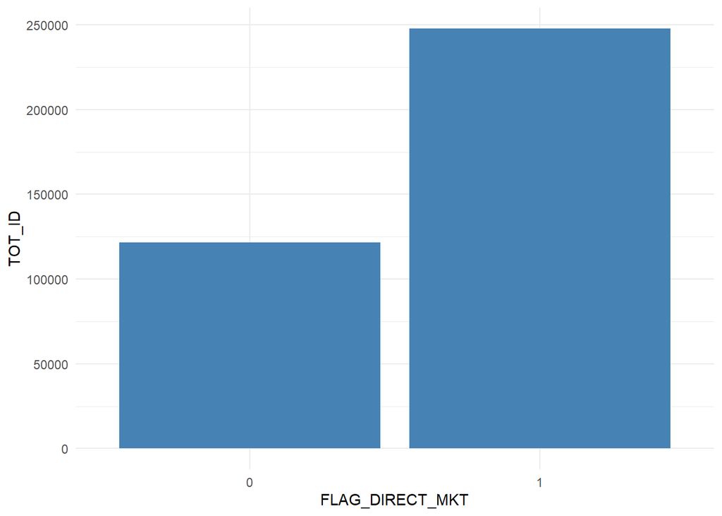

```r
ggplot(data = df4_dist_privacy_mkt,
       aes(x = FLAG_DIRECT_MKT,
           y = TOT_ID)) +
  geom_bar(stat = "identity",
           fill = "steelblue") +
  theme_minimal()
```

## 5. Campaign Category

The campaign channel (`CHANNEL_CAMP`) is not importants: let’s remove it.

```r
campaign_category_clean <- campaign_category_clean %>%
                             select(-CHANNEL_CAMP)
```

## 6. Campaign Event

Let’s format dates and times:

```r
campaign_event_clean <- campaign_event_clean %>%
                              mutate(EVENT_DATETIME = as.POSIXct(EVENT_DATE, format="%Y-%m-%dT%H:%M:%S")) %>%
                              mutate(EVENT_HOUR = hour(EVENT_DATETIME)) %>%
                              mutate(EVENT_DATE = as.Date(EVENT_DATETIME))
```

### Reshaping

We remap the event type values `E` (*ERROR*) and `B` [*BOUNCE*] into a level `F` [*FAILURE*]:

```r
campaign_event_clean <- campaign_event_clean %>%
                          mutate(TYP_EVENT = as.factor(if_else(TYP_EVENT == "E" | TYP_EVENT == "B",
                                                               "F", as.character(TYP_EVENT)))) %>%
                          left_join(campaign_category_clean,
                                    by = "ID_CAMP")
```

Also, is necessary to organize the data adding to each sending event the corresponding opens/clicks/fails:

```r
df_sends <- campaign_event_clean %>%
              filter(TYP_EVENT == "S") %>%
              select(-TYP_EVENT) %>%
              select(ID_EVENT_S = ID_EVENT,
                     ID_CLI,
                     ID_CAMP,
                     TYP_CAMP,
                     ID_DELIVERY,
                     SEND_DATE = EVENT_DATE) %>%
              as.data.frame()
```

There could be multiple opens of the same communication:

1. Count the open events;
2. Consider explicitely only the first open.

```r
df_opens_prep <- campaign_event_clean %>%
                    filter(TYP_EVENT == "V") %>%
                    select(-TYP_EVENT) %>%
                    select(ID_EVENT_O = ID_EVENT,
                           ID_CLI,
                           ID_CAMP,
                           TYP_CAMP,
                           ID_DELIVERY,
                           OPEN_DATETIME = EVENT_DATETIME,
                           OPEN_DATE = EVENT_DATE) %>%
                    as.data.frame()

total_opens <- df_opens_prep %>%
  group_by(ID_CLI,
           ID_CAMP,
           ID_DELIVERY) %>%
  summarize(NUM_OPENs = n_distinct(ID_EVENT_O))

df_opens <- df_opens_prep %>%
  left_join(total_opens,
            by = c("ID_CLI", "ID_CAMP", "ID_DELIVERY")) %>%
  group_by(ID_CLI,
           ID_CAMP,
           ID_DELIVERY) %>%
  filter(OPEN_DATETIME == min(OPEN_DATETIME)) %>%
  filter(row_number() == 1) %>%
  ungroup() %>%
  as.data.frame()
```

There could be multiple clicks of the same communication:

1. Count the click events;
2. Consider explicitely only the first click.

```r
df_clicks_prep <- campaign_event_clean %>%
  filter(TYP_EVENT == "C") %>%
  select(-TYP_EVENT) %>%
  select(ID_EVENT_C = ID_EVENT,
         ID_CLI,
         ID_CAMP,
         TYP_CAMP,
         ID_DELIVERY,
         CLICK_DATETIME = EVENT_DATETIME,
         CLICK_DATE = EVENT_DATE)

total_clicks <- df_clicks_prep %>%
  group_by(ID_CLI,
           ID_CAMP,
           ID_DELIVERY) %>%
  summarize(NUM_CLICKs = n_distinct(ID_EVENT_C))

df_clicks <- df_clicks_prep %>%
  left_join(total_clicks,
            by = c("ID_CLI", "ID_CAMP", "ID_DELIVERY")) %>%
  group_by(ID_CLI,
           ID_CAMP,
           ID_DELIVERY) %>%
  filter(CLICK_DATETIME == min(CLICK_DATETIME)) %>%
  filter(row_number() == 1) %>%
  ungroup() %>%
  as.data.frame()
```

```r
df_fails <- campaign_event_clean %>%
  filter(TYP_EVENT == "F") %>%
  select(-TYP_EVENT) %>%
  select(ID_EVENT_F = ID_EVENT,
         ID_CLI,
         ID_CAMP,
         TYP_CAMP,
         ID_DELIVERY,
         FAIL_DATETIME = EVENT_DATETIME,
         FAIL_DATE = EVENT_DATE) %>%
  group_by(ID_CLI, ID_CAMP, ID_DELIVERY) %>%
  filter(FAIL_DATETIME == min(FAIL_DATETIME)) %>%
  filter(row_number() == 1) %>%
  ungroup() %>%
  as.data.frame()
```

We combine them in one variable:

```r
campaign_event_clean_final <- df_sends %>%
  left_join(df_opens,
            by = c("ID_CLI", "ID_CAMP", "ID_DELIVERY", "TYP_CAMP")
  ) %>%
  filter(is.na(OPEN_DATE) | SEND_DATE <= OPEN_DATE) %>%
  left_join(df_clicks,
            by = c("ID_CLI", "ID_CAMP", "ID_DELIVERY", "TYP_CAMP")
  ) %>%
  filter(is.na(CLICK_DATE) | OPEN_DATE <= CLICK_DATE) %>%
  left_join(df_fails,
            by = c("ID_CLI", "ID_CAMP", "ID_DELIVERY", "TYP_CAMP")
  ) %>%
  filter(is.na(FAIL_DATE) | SEND_DATE <= FAIL_DATE) %>%
  mutate(OPENED = !is.na(ID_EVENT_O)) %>%
  mutate(CLICKED = !is.na(ID_EVENT_C)) %>%
  mutate(FAILED = !is.na(ID_EVENT_F)) %>%
  mutate(DAYS_TO_OPEN = as.integer(OPEN_DATE - SEND_DATE)) %>%
  select(ID_EVENT_S,
         ID_CLI,
         ID_CAMP,
         TYP_CAMP,
         ID_DELIVERY,
         SEND_DATE,
         OPENED,
         OPEN_DATE,
         DAYS_TO_OPEN,
         NUM_OPENs,
         CLICKED,
         CLICK_DATE,
         NUM_CLICKs,
         FAILED)
```

### Explanatory Analysis

```r
df6_overview <- campaign_event_clean_final %>%
  summarize(MIN_DATE = min(SEND_DATE),
            MAX_DATE = max(SEND_DATE),
            TOT_EVENTs = n_distinct(ID_EVENT_S),
            TOT_CLIs = n_distinct(ID_CLI))

knitr::kable(df6_overview)
```

| MIN_DATE | MAX_DATE | TOT_EVENTs | TOT_CLIs |
| --- | --- | --- | --- |
| 2019-01-03 | 2019-04-30 | 1556646 | 190427 |

Below there’s a general overview about the type of campaign variable (`TYP_CAMP`):

```r
df6_overviewbytyp <- campaign_event_clean_final %>%
  group_by(TYP_CAMP) %>%
  summarize(MIN_DATE = min(SEND_DATE),
            MAX_DATE = max(SEND_DATE),
            TOT_EVENTs = n_distinct(ID_EVENT_S),
            TOT_CLIs = n_distinct(ID_CLI))

knitr::kable(df6_overviewbytyp)
```

| TYP_CAMP | MIN_DATE | MAX_DATE | TOT_EVENTs | TOT_CLIs |
| --- | --- | --- | --- | --- |
| LOCAL | 2019-02-02 | 2019-04-02 | 151719 | 87894 |
| NATIONAL | 2019-01-07 | 2019-04-23 | 833085 | 177153 |
| PERSONALIZED | 2019-01-03 | 2019-04-30 | 194840 | 133908 |
| PRODUCT | 2019-01-03 | 2019-04-25 | 377002 | 69724 |

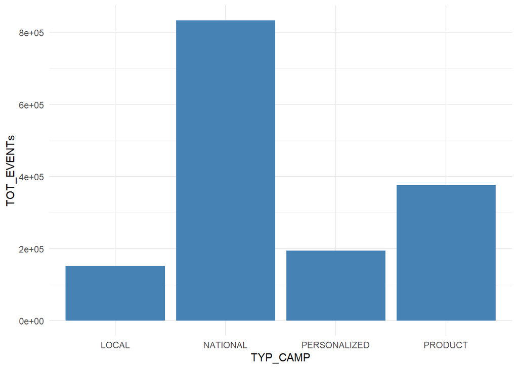

```r
ggplot(data = df6_overviewbytyp,
       aes(x = TYP_CAMP,
           y = TOT_EVENTs)) +
  geom_bar(stat = "identity",
           fill = "steelblue") +
  theme_minimal()
```

Below there’s a general overview about the variable `OPENED`:

```r
df6_dist_opened <- campaign_event_clean_final %>%
  group_by(OPENED) %>%
  summarize(TOT_EVENTs = n_distinct(ID_EVENT_S),
            TOT_CLIs = n_distinct(ID_CLI)) %>%
  mutate(TYP_CAMP = 'ALL') %>%
  mutate(PERCENT_EVENTs = TOT_EVENTs/df6_overview$TOT_EVENTs,
         PERCENT_CLIs = TOT_CLIs/df6_overview$TOT_CLIs)

knitr::kable(df6_dist_opened)
```

| OPENED | TOT_EVENTs | TOT_CLIs | TYP_CAMP | PERCENT_EVENTs | PERCENT_CLIs |
| --- | --- | --- | --- | --- | --- |
| FALSE | 1278264 | 178378 | ALL | 0.8211655 | 0.9367264 |
| TRUE | 278382 | 83420 | ALL | 0.1788345 | 0.4380681 |

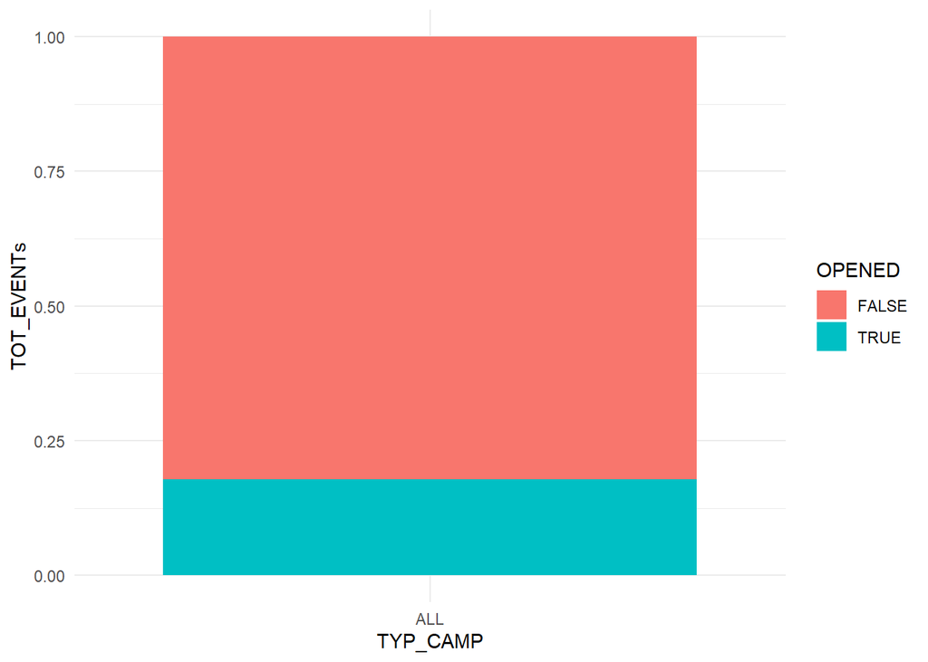

```r
  ggplot(data = df6_dist_opened,
         aes(fill = OPENED,
             x = TYP_CAMP,
             y = TOT_EVENTs)) +
    geom_bar(stat = "identity",
             position = "fill") +
    theme_minimal()
```

Below there’s a general overview about the type of campaign variable opened (`TYP_CAMP`):

```r
df6_dist_openedbytyp <- campaign_event_clean_final %>%
  group_by(TYP_CAMP, OPENED)  %>%
  summarize(TOT_EVENTs = n_distinct(ID_EVENT_S),
            TOT_CLIs = n_distinct(ID_CLI)) %>%
  left_join(df6_overviewbytyp %>%
              select(TYP_CAMP,
                     ALL_TOT_EVENTs = TOT_EVENTs,
                     ALL_TOT_CLIs = TOT_CLIs),
            by = 'TYP_CAMP') %>%
  mutate(PERCENT_EVENTs = TOT_EVENTs/ALL_TOT_EVENTs,
         PERCENT_CLIs = TOT_CLIs/ALL_TOT_CLIs) %>%
  select(TYP_CAMP,
         OPENED,
         TOT_EVENTs,
         TOT_CLIs,
         PERCENT_EVENTs,
         PERCENT_CLIs)

knitr::kable(df6_dist_openedbytyp)
```

| TYP_CAMP | OPENED | TOT_EVENTs | TOT_CLIs | PERCENT_EVENTs | PERCENT_CLIs |
| --- | --- | --- | --- | --- | --- |
| LOCAL | FALSE | 126700 | 76835 | 0.8350965 | 0.8741780 |
| LOCAL | TRUE | 25019 | 18029 | 0.1649035 | 0.2051221 |
| NATIONAL | FALSE | 710721 | 162049 | 0.8531194 | 0.9147404 |
| NATIONAL | TRUE | 122364 | 62964 | 0.1468806 | 0.3554216 |
| PERSONALIZED | FALSE | 156431 | 111942 | 0.8028690 | 0.8359620 |
| PERSONALIZED | TRUE | 38409 | 31327 | 0.1971310 | 0.2339442 |
| PRODUCT | FALSE | 284412 | 62356 | 0.7544045 | 0.8943262 |
| PRODUCT | TRUE | 92590 | 29605 | 0.2455955 | 0.4246027 |

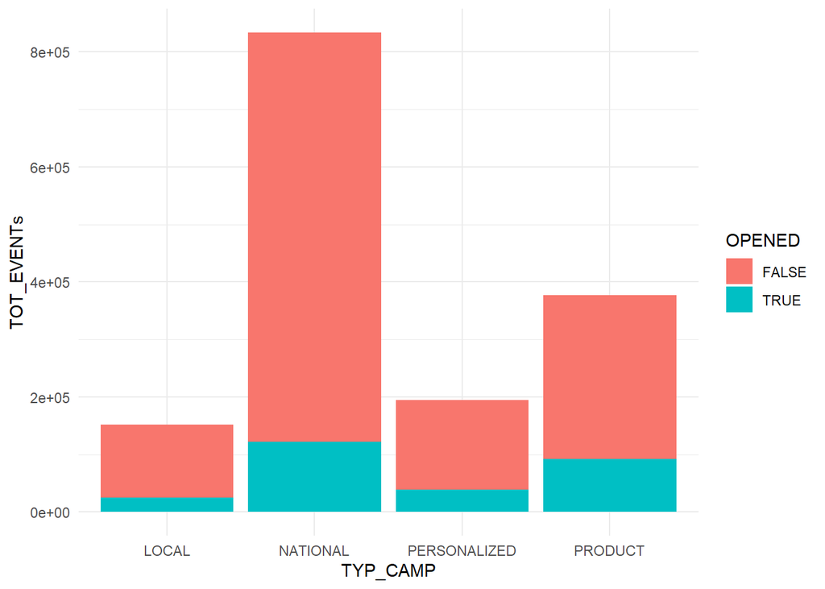

```r
ggplot(data = df6_dist_openedbytyp,
       aes(fill = OPENED,
           x = TYP_CAMP,
           y = TOT_EVENTs)) +
  geom_bar(stat = "identity") +
  theme_minimal()
```

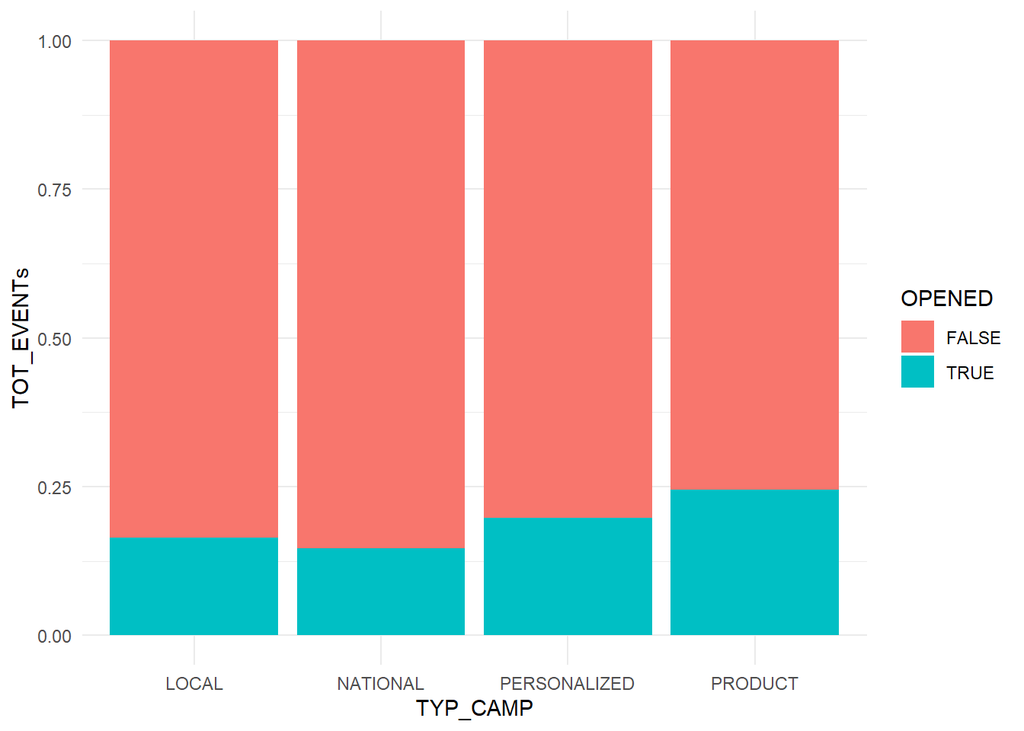

```r
ggplot(data = df6_dist_openedbytyp,
       aes(fill = OPENED,
           x = TYP_CAMP,
           y = TOT_EVENTs)) +
  geom_bar(position = "fill",
           stat = "identity") +
  theme_minimal()
```

Below there’s a general overview about the days after an email is opened (`DAYS_TO_OPEN`):

```r
df6_dist_daystoopen <- campaign_event_clean_final %>%
  filter(OPENED) %>%
  group_by(ID_CLI) %>%
  summarize(AVG_DAYS_TO_OPEN = floor(mean(DAYS_TO_OPEN))) %>%
  ungroup() %>%
  group_by(AVG_DAYS_TO_OPEN) %>%
  summarize(TOT_CLIs = n_distinct(ID_CLI))

knitr::kable(df6_dist_daystoopen)
```

| AVG_DAYS_TO_OPEN | TOT_CLIs |
| --- | --- |
| 0 | 53094 |
| 1 | 12383 |
| 2 | 4906 |
| 3 | 3066 |
| 4 | 2147 |
| 5 | 1459 |
| 6 | 1170 |
| 7 | 789 |
| 8 | 567 |
| 9 | 482 |
| 10 | 397 |
| 11 | 365 |
| 12 | 332 |
| 13 | 284 |
| 14 | 241 |
| 15 | 170 |
| 16 | 169 |
| 17 | 146 |
| 18 | 138 |
| 19 | 124 |
| 20 | 128 |
| 21 | 104 |
| 22 | 72 |
| 23 | 75 |
| 24 | 67 |
| 25 | 49 |
| 26 | 55 |
| 27 | 45 |
| 28 | 46 |
| 29 | 36 |
| 30 | 29 |
| 31 | 24 |
| 32 | 26 |
| 33 | 19 |
| 34 | 22 |
| 35 | 12 |
| 36 | 10 |
| 37 | 13 |
| 38 | 12 |
| 39 | 15 |
| 40 | 10 |
| 41 | 13 |
| 42 | 16 |
| 43 | 6 |
| 44 | 8 |
| 45 | 13 |
| 46 | 7 |
| 47 | 5 |
| 48 | 9 |
| 49 | 6 |
| 50 | 3 |
| 51 | 3 |
| 52 | 5 |
| 53 | 3 |
| 54 | 6 |
| 55 | 10 |
| 56 | 6 |
| 57 | 2 |
| 58 | 1 |

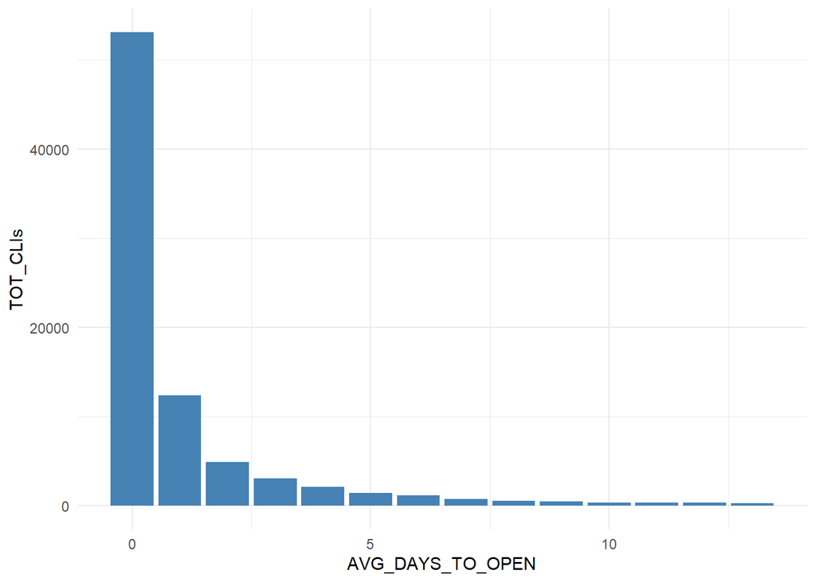

```r
ggplot(data = df6_dist_daystoopen %>%
         filter(AVG_DAYS_TO_OPEN < 14),
       aes(x = AVG_DAYS_TO_OPEN,
           y = TOT_CLIs)) +
  geom_bar(stat = "identity",
           fill = "steelblue") +
  theme_minimal()
```

Below there’s a general overview about the days after an email is opened (`DAYS_TO_OPEN`):

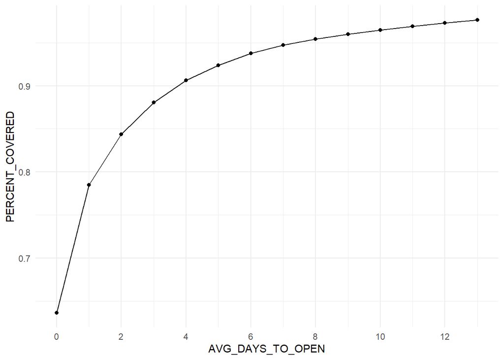

```r
df6_dist_daystoopen_vs_cumulate <- df6_dist_daystoopen %>%
  arrange(AVG_DAYS_TO_OPEN) %>%
  mutate(PERCENT_COVERED = cumsum(TOT_CLIs)/sum(TOT_CLIs))

ggplot(data = df6_dist_daystoopen_vs_cumulate %>%
         filter(AVG_DAYS_TO_OPEN < 14),
       aes(x = AVG_DAYS_TO_OPEN,
           y = PERCENT_COVERED)) +
  geom_line() +
  geom_point() +
  scale_x_continuous(breaks = seq(0,14,2), minor_breaks = 0:14) +
  theme_minimal()
```

Below there’s a general overview about the days after an email is clicked:

```r
df6_dist_clickedbytyp <- campaign_event_clean_final %>%
  group_by(TYP_CAMP, CLICKED)  %>%
  summarize(TOT_EVENTs = n_distinct(ID_EVENT_S),
            TOT_CLIs = n_distinct(ID_CLI)) %>%
  left_join(df6_overviewbytyp %>%
              select(TYP_CAMP,
                     ALL_TOT_EVENTs = TOT_EVENTs,
                     ALL_TOT_CLIs = TOT_CLIs)
            , by='TYP_CAMP') %>%
  mutate(PERCENT_EVENTs = TOT_EVENTs/ALL_TOT_EVENTs,
         PERCENT_CLIs = TOT_CLIs/ALL_TOT_CLIs) %>%
  select(TYP_CAMP,
         CLICKED,
         TOT_EVENTs,
         TOT_CLIs,
         PERCENT_EVENTs,
         PERCENT_CLIs)

knitr::kable(df6_dist_clickedbytyp)
```

| TYP_CAMP | CLICKED | TOT_EVENTs | TOT_CLIs | PERCENT_EVENTs | PERCENT_CLIs |
| --- | --- | --- | --- | --- | --- |
| LOCAL | FALSE | 150374 | 87332 | 0.9911349 | 0.9936059 |
| LOCAL | TRUE | 1345 | 1280 | 0.0088651 | 0.0145630 |
| NATIONAL | FALSE | 815796 | 175939 | 0.9792470 | 0.9931472 |
| NATIONAL | TRUE | 17289 | 14216 | 0.0207530 | 0.0802470 |
| PERSONALIZED | FALSE | 192741 | 133043 | 0.9892271 | 0.9935403 |
| PERSONALIZED | TRUE | 2099 | 2016 | 0.0107729 | 0.0150551 |
| PRODUCT | FALSE | 362551 | 69373 | 0.9616686 | 0.9949659 |
| PRODUCT | TRUE | 14451 | 8800 | 0.0383314 | 0.1262119 |

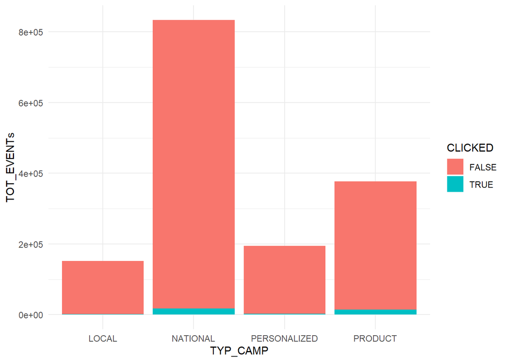

```r
ggplot(data = df6_dist_clickedbytyp,
       aes(fill = CLICKED, x = TYP_CAMP, y = TOT_EVENTs)) +
  geom_bar(stat = "identity") +
  theme_minimal()
```

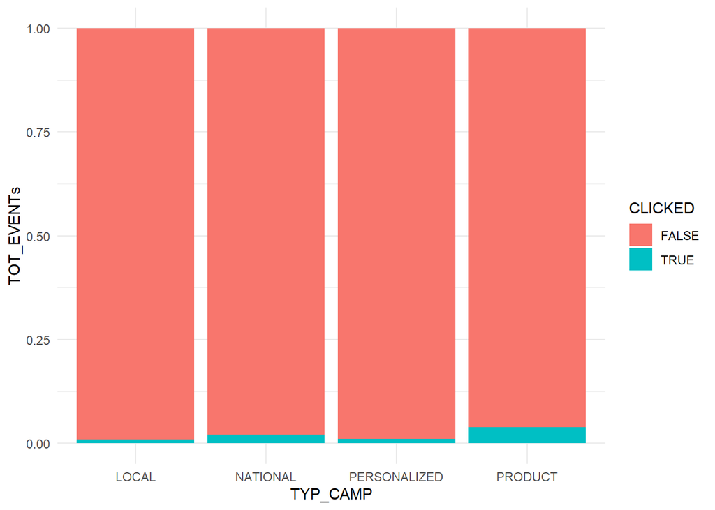

```r
ggplot(data = df6_dist_clickedbytyp,
       aes(fill = CLICKED,
             x = TYP_CAMP,
             y = TOT_EVENTs)) +
  geom_bar(position = "fill",
           stat = "identity") +
  theme_minimal()
```

Below there’s a general overview about the days after an email is failed:

```r
df6_dist_failedbytyp <- campaign_event_clean_final %>%
  group_by(TYP_CAMP, FAILED)  %>%
  summarize(TOT_EVENTs = n_distinct(ID_EVENT_S)
            , TOT_CLIs = n_distinct(ID_CLI)) %>%
  left_join(df6_overviewbytyp %>%
              select(TYP_CAMP,
                     ALL_TOT_EVENTs = TOT_EVENTs,
                     ALL_TOT_CLIs = TOT_CLIs),
            by='TYP_CAMP') %>%
  mutate(PERCENT_EVENTs = TOT_EVENTs/ALL_TOT_EVENTs,
         PERCENT_CLIs = TOT_CLIs/ALL_TOT_CLIs) %>%
  select(TYP_CAMP,
         FAILED,
         TOT_EVENTs,
         TOT_CLIs,
         PERCENT_EVENTs,
         PERCENT_CLIs)

knitr::kable(df6_dist_failedbytyp)
```

| TYP_CAMP | FAILED | TOT_EVENTs | TOT_CLIs | PERCENT_EVENTs | PERCENT_CLIs |
| --- | --- | --- | --- | --- | --- |
| LOCAL | FALSE | 149189 | 86540 | 0.9833244 | 0.9845951 |
| LOCAL | TRUE | 2530 | 1653 | 0.0166756 | 0.0188067 |
| NATIONAL | FALSE | 814897 | 174425 | 0.9781679 | 0.9846009 |
| NATIONAL | TRUE | 18188 | 7045 | 0.0218321 | 0.0397679 |
| PERSONALIZED | FALSE | 192844 | 132774 | 0.9897557 | 0.9915315 |
| PERSONALIZED | TRUE | 1996 | 1690 | 0.0102443 | 0.0126206 |
| PRODUCT | FALSE | 371788 | 68960 | 0.9861698 | 0.9890425 |
| PRODUCT | TRUE | 5214 | 1729 | 0.0138302 | 0.0247978 |

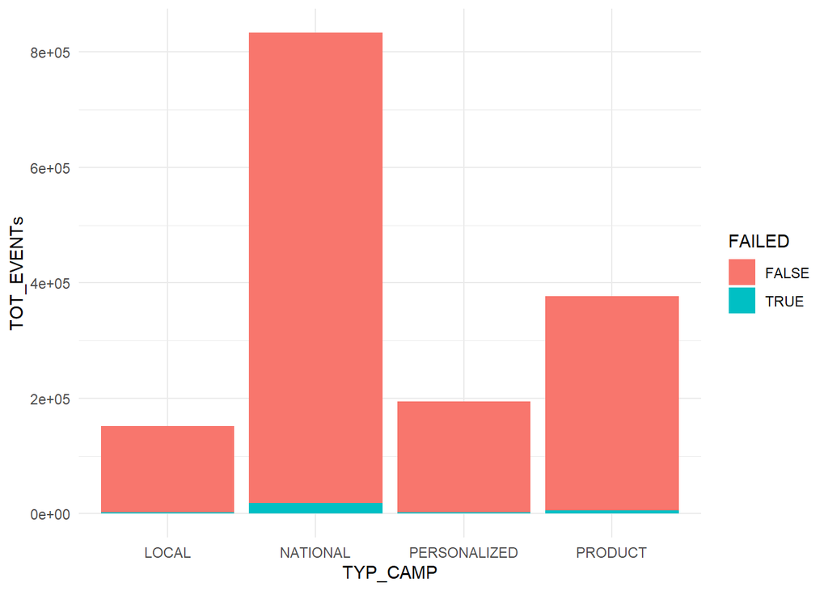

```r
ggplot(data = df6_dist_failedbytyp,
       aes(fill = FAILED,
           x = TYP_CAMP,
           y = TOT_EVENTs)) +
  geom_bar(stat = "identity") +
  theme_minimal()
```

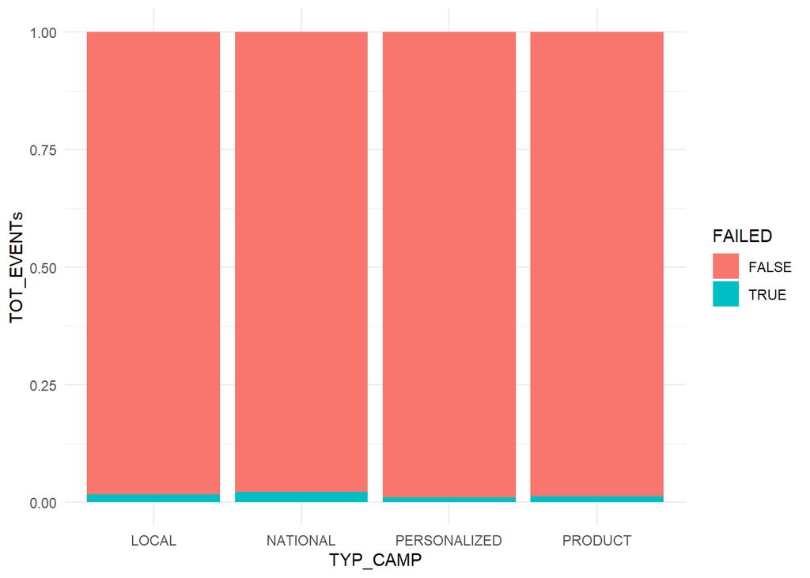

```r
ggplot(data = df6_dist_failedbytyp,
       aes(fill = FAILED,
           x = TYP_CAMP,
           y = TOT_EVENTs)) +
  geom_bar(position = "fill",
           stat = "identity") +
  theme_minimal()
```

Below there’s a general overview about the number of clicks opening an email:

```r
df6_dist_numopens<- campaign_event_clean_final %>%
  group_by(NUM_OPENs) %>%
  summarize(TOT_ID = n_distinct(ID_EVENT_S)) %>%
  mutate(PERCENT = TOT_ID/sum(TOT_ID)) %>%
  arrange(desc(PERCENT))

df6_dist_numopens
```

```
## # A tibble: 45 x 3
##    NUM_OPENs  TOT_ID  PERCENT
##        <int>   <int>    <dbl>
##  1        NA 1278264 0.821
##  2         1  220900 0.142
##  3         2   37877 0.0243
##  4         3   11058 0.00710
##  5         4    4002 0.00257
##  6         5    1833 0.00118
##  7         6    1028 0.000660
##  8         7     568 0.000365
##  9         8     326 0.000209
## 10         9     227 0.000146
## # ... with 35 more rows
```

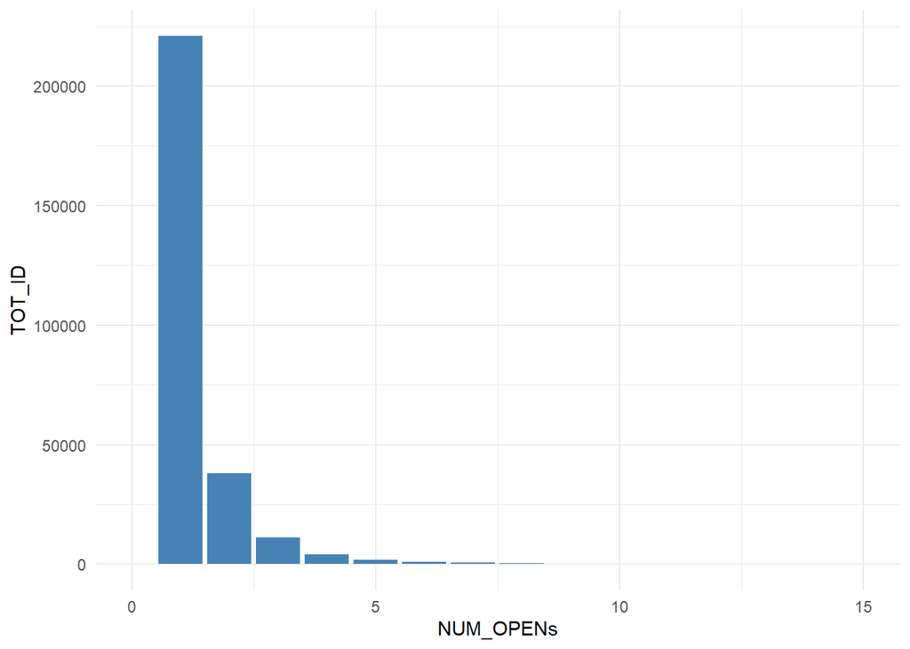

```r
plot_df6_dist_numopens <- (
  ggplot(data = df6_dist_numopens
         , aes(x = NUM_OPENs, y = TOT_ID)) +
    geom_bar(stat = "identity"
             , fill = "steelblue") +
    xlim(0, 15)+
    theme_minimal()
)

plot_df6_dist_numopens
```

Below there’s a general overview about the number of clicks in the email:

```r
df6_dist_numclicks <- campaign_event_clean_final %>%
  group_by(NUM_CLICKs) %>%
  summarize(TOT_ID = n_distinct(ID_EVENT_S)) %>%
  mutate(PERCENT = TOT_ID/sum(TOT_ID)) %>%
  arrange(desc(PERCENT))


knitr::kable(df6_dist_numclicks)
```

| NUM_CLICKs | TOT_ID | PERCENT |
| --- | --- | --- |
| NA | 1521462 | 0.9773976 |
| 1 | 26912 | 0.0172885 |
| 2 | 5586 | 0.0035885 |
| 3 | 1604 | 0.0010304 |
| 4 | 593 | 0.0003809 |
| 5 | 263 | 0.0001690 |
| 6 | 88 | 0.0000565 |
| 7 | 56 | 0.0000360 |
| 8 | 27 | 0.0000173 |
| 9 | 27 | 0.0000173 |
| 10 | 9 | 0.0000058 |
| 13 | 4 | 0.0000026 |
| 11 | 3 | 0.0000019 |
| 12 | 3 | 0.0000019 |
| 14 | 2 | 0.0000013 |
| 24 | 2 | 0.0000013 |
| 15 | 1 | 0.0000006 |
| 16 | 1 | 0.0000006 |
| 18 | 1 | 0.0000006 |
| 19 | 1 | 0.0000006 |
| 41 | 1 | 0.0000006 |

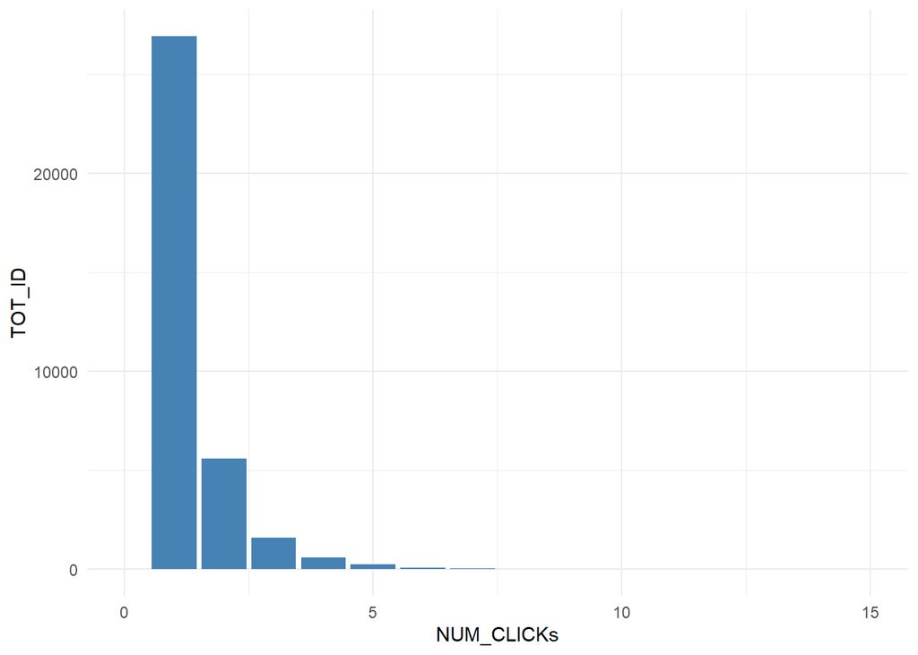

```r
ggplot(data = df6_dist_numclicks,
       aes(x = NUM_CLICKs, y = TOT_ID)) +
  geom_bar(stat = "identity",
           fill = "steelblue") +
  xlim(0, 15) +
  theme_minimal()
```

## 7. Purchase and Refund

Let’s format dates and times and factorize `DIREZIONE`:

```r
tickets_clean <- tickets_clean %>%
                    mutate(TIC_DATETIME = as.POSIXct(DATETIME, format = "%Y-%m-%dT%H%M%S")) %>%
                    mutate(TIC_HOUR = hour(TIC_DATETIME)) %>%
                    mutate(TIC_DATE = as.Date(TIC_DATETIME)) %>%
                    select(-DATETIME) %>%
                    mutate(DIREZIONE = as.factor(DIREZIONE)) %>% #-- Factorization
                    mutate(COD_REPARTO = as.factor(COD_REPARTO))
```

### Reshaping

```r
tickets_clean <- tickets_clean %>%
                    #-- adding day characterization
                    mutate(TIC_DATE_WEEKDAY = wday(TIC_DATE)) %>%
                    mutate(TIC_DATE_HOLIDAY = isHoliday("Italy", TIC_DATE)) %>%
                    mutate(TIC_DATE_TYP = case_when(
                      (TIC_DATE_WEEKDAY %in% c(6,7)) ~ "weekend",
                      (TIC_DATE_HOLIDAY == TRUE) ~ "holiday",
                      (TIC_DATE_WEEKDAY < 7) ~ "weekday",
                      TRUE ~ "other"))
```

### Explanatory Analysis

Let’s take a general overiew about the `TIC_DATE` variable:

```r
df7_overview <- tickets_clean %>%
                  summarize(MIN_DATE = min(TIC_DATE),
                            MAX_DATE = max(TIC_DATE),
                            TOT_TICs = n_distinct(ID_SCONTRINO),
                            TOT_CLIs = n_distinct(ID_CLI))

knitr::kable(df7_overview)
```

| MIN_DATE | MAX_DATE | TOT_TICs | TOT_CLIs |
| --- | --- | --- | --- |
| 2018-05-01 | 2019-04-30 | 998035 | 212124 |

Let’s take a general overiew about the `DIREZIONE` variable:

```r
df7_dist_direction <- tickets_clean %>%
  group_by(DIREZIONE) %>%
  summarize(TOT_TICs = n_distinct(ID_SCONTRINO),
            TOT_CLIs = n_distinct(ID_CLI)) %>%
  mutate(PERCENT_TICs = TOT_TICs/df7_overview$TOT_TICs,
         PERCENT_CLIs = TOT_CLIs/df7_overview$TOT_CLIs)

knitr::kable(df7_dist_direction)
```

| DIREZIONE | TOT_TICs | TOT_CLIs | PERCENT_TICs | PERCENT_CLIs |
| --- | --- | --- | --- | --- |
| -1 | 90189 | 46622 | 0.0903666 | 0.2197865 |
| 1 | 907846 | 212124 | 0.9096334 | 1.0000000 |

Let’s take a general overiew about the `TIC_HOURS` variable:

```r
df7_dist_hour <- tickets_clean %>%
  group_by(TIC_HOUR, DIREZIONE) %>%
  summarize(TOT_TICs = n_distinct(ID_SCONTRINO),
            TOT_CLIs = n_distinct(ID_CLI)) %>%
  left_join(df7_dist_direction %>%
              select(DIREZIONE,
                     ALL_TOT_TICs = TOT_TICs,
                     ALL_TOT_CLIs = TOT_CLIs),
            by = 'DIREZIONE') %>%
  mutate(PERCENT_TICs = TOT_TICs/ALL_TOT_TICs,
         PERCENT_CLIs = TOT_CLIs/ALL_TOT_CLIs) %>%
  select(-ALL_TOT_TICs,
         -ALL_TOT_CLIs)

knitr::kable(df7_dist_hour)
```

| TIC_HOUR | DIREZIONE | TOT_TICs | TOT_CLIs | PERCENT_TICs | PERCENT_CLIs |
| --- | --- | --- | --- | --- | --- |
| 3 | 1 | 2 | 2 | 0.0000022 | 0.0000094 |
| 4 | 1 | 4 | 4 | 0.0000044 | 0.0000189 |
| 5 | 1 | 2 | 2 | 0.0000022 | 0.0000094 |
| 6 | 1 | 32 | 32 | 0.0000352 | 0.0001509 |
| 7 | -1 | 759 | 638 | 0.0084157 | 0.0136845 |
| 7 | 1 | 9249 | 6309 | 0.0101879 | 0.0297420 |
| 8 | -1 | 1767 | 1468 | 0.0195922 | 0.0314873 |
| 8 | 1 | 17678 | 11624 | 0.0194725 | 0.0547981 |
| 9 | -1 | 5888 | 4681 | 0.0652851 | 0.1004032 |
| 9 | 1 | 45619 | 29290 | 0.0502497 | 0.1380796 |
| 10 | -1 | 8165 | 6551 | 0.0905321 | 0.1405131 |
| 10 | 1 | 73007 | 46140 | 0.0804178 | 0.2175143 |
| 11 | -1 | 8846 | 7092 | 0.0980829 | 0.1521170 |
| 11 | 1 | 87016 | 55356 | 0.0958489 | 0.2609606 |
| 12 | -1 | 7575 | 6139 | 0.0839903 | 0.1316760 |
| 12 | 1 | 80949 | 53217 | 0.0891660 | 0.2508768 |
| 13 | -1 | 6050 | 4925 | 0.0670814 | 0.1056368 |
| 13 | 1 | 62928 | 42806 | 0.0693157 | 0.2017971 |
| 14 | -1 | 6235 | 5133 | 0.0691326 | 0.1100982 |
| 14 | 1 | 59134 | 40689 | 0.0651366 | 0.1918171 |
| 15 | -1 | 7915 | 6472 | 0.0877601 | 0.1388186 |
| 15 | 1 | 73277 | 49371 | 0.0807152 | 0.2327459 |
| 16 | -1 | 8738 | 7114 | 0.0968854 | 0.1525889 |
| 16 | 1 | 87243 | 58148 | 0.0960989 | 0.2741227 |
| 17 | -1 | 9247 | 7422 | 0.1025291 | 0.1591952 |
| 17 | 1 | 93814 | 60966 | 0.1033369 | 0.2874074 |
| 18 | -1 | 9460 | 7471 | 0.1048908 | 0.1602462 |
| 18 | 1 | 95487 | 60000 | 0.1051797 | 0.2828534 |
| 19 | -1 | 7213 | 5665 | 0.0799765 | 0.1215092 |
| 19 | 1 | 83714 | 51013 | 0.0922117 | 0.2404867 |
| 20 | -1 | 2213 | 1834 | 0.0245374 | 0.0393377 |
| 20 | 1 | 36242 | 23761 | 0.0399209 | 0.1120147 |
| 21 | -1 | 115 | 108 | 0.0012751 | 0.0023165 |
| 21 | 1 | 2373 | 1850 | 0.0026139 | 0.0087213 |
| 22 | -1 | 3 | 3 | 0.0000333 | 0.0000643 |
| 22 | 1 | 76 | 69 | 0.0000837 | 0.0003253 |

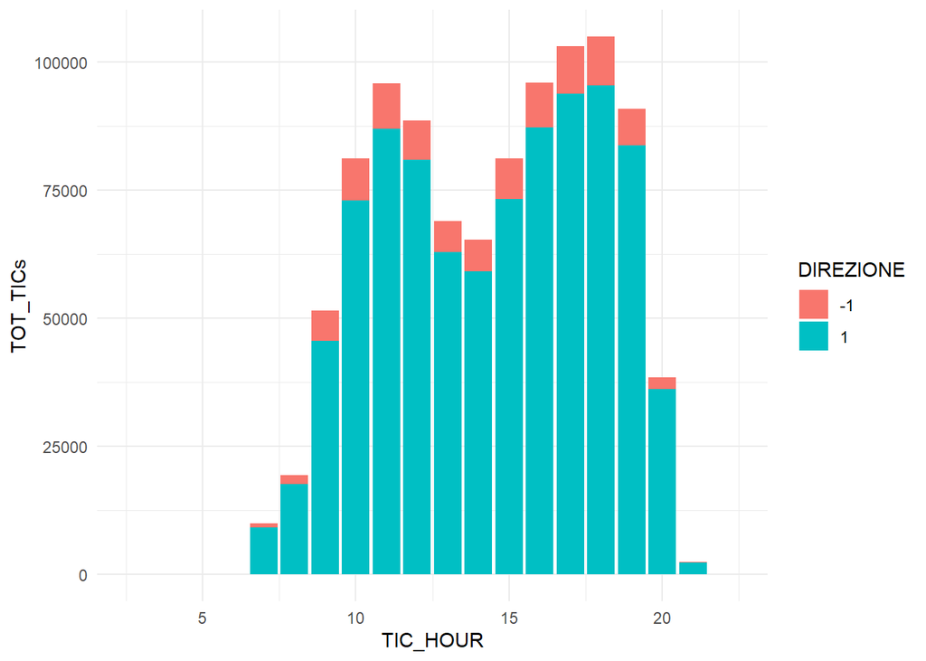

```r
#-- TIC_HOURS
ggplot(data = df7_dist_hour,
       aes(fill = DIREZIONE,
           x = TIC_HOUR,
           y = TOT_TICs)) +
  geom_bar(stat = "identity") +
  theme_minimal()
```

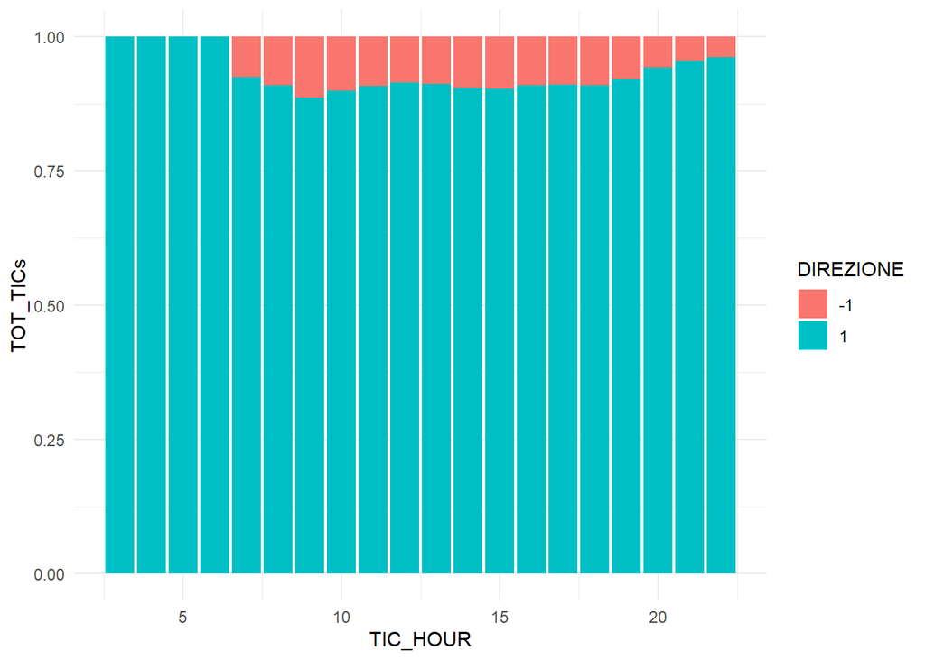

```r
#-- TIC_HOURS Percent
ggplot(data = df7_dist_hour,
       aes(fill = DIREZIONE,
           x = TIC_HOUR,
           y = TOT_TICs)) +
  geom_bar(stat = "identity",
           position = "fill" ) +
  theme_minimal()
```

Let’s take a general overiew about the `COD_REPARTO` variable:

```r
df7_dist_dep <- tickets_clean %>%
  group_by(COD_REPARTO, DIREZIONE) %>%
  summarize(TOT_TICs = n_distinct(ID_SCONTRINO),
            TOT_CLIs = n_distinct(ID_CLI)) %>%
  left_join(df7_dist_direction %>%
              select(DIREZIONE,
                     ALL_TOT_TICs = TOT_TICs,
                     ALL_TOT_CLIs = TOT_CLIs),
            by = 'DIREZIONE') %>%
  mutate(PERCENT_TICs = TOT_TICs/ALL_TOT_TICs,
         PERCENT_CLIs = TOT_CLIs/ALL_TOT_CLIs) %>%
    select(-ALL_TOT_TICs, -ALL_TOT_CLIs)

knitr::kable(df7_dist_dep)
```

| COD_REPARTO | DIREZIONE | TOT_TICs | TOT_CLIs | PERCENT_TICs | PERCENT_CLIs |
| --- | --- | --- | --- | --- | --- |
| 1 | -1 | 2512 | 1928 | 0.0278526 | 0.0413539 |
| 1 | 1 | 65151 | 30531 | 0.0717644 | 0.1439300 |
| 2 | -1 | 5604 | 4598 | 0.0621362 | 0.0986230 |
| 2 | 1 | 94618 | 54055 | 0.1042225 | 0.2548274 |
| 3 | -1 | 17083 | 10835 | 0.1894133 | 0.2324010 |
| 3 | 1 | 229972 | 93224 | 0.2533161 | 0.4394788 |
| 4 | -1 | 3139 | 2761 | 0.0348047 | 0.0592210 |
| 4 | 1 | 144544 | 73069 | 0.1592164 | 0.3444636 |
| 5 | -1 | 2374 | 2035 | 0.0263225 | 0.0436489 |
| 5 | 1 | 41220 | 29916 | 0.0454042 | 0.1410307 |
| 6 | -1 | 11834 | 7666 | 0.1312133 | 0.1644288 |
| 6 | 1 | 84258 | 39747 | 0.0928109 | 0.1873763 |
| 7 | -1 | 14120 | 10791 | 0.1565601 | 0.2314573 |
| 7 | 1 | 165422 | 86114 | 0.1822137 | 0.4059607 |
| 8 | -1 | 4291 | 3416 | 0.0475779 | 0.0732701 |
| 8 | 1 | 41756 | 27564 | 0.0459946 | 0.1299429 |
| 9 | -1 | 4763 | 4046 | 0.0528113 | 0.0867831 |
| 9 | 1 | 159089 | 82354 | 0.1752379 | 0.3882352 |
| 10 | -1 | 7965 | 6353 | 0.0883145 | 0.1362661 |
| 10 | 1 | 255146 | 105352 | 0.2810455 | 0.4966529 |
| 11 | -1 | 6135 | 4886 | 0.0680238 | 0.1048003 |
| 11 | 1 | 195671 | 87540 | 0.2155333 | 0.4126831 |
| 12 | -1 | 8450 | 6707 | 0.0936921 | 0.1438591 |
| 12 | 1 | 121615 | 69672 | 0.1339599 | 0.3284494 |
| 13 | -1 | 10767 | 8496 | 0.1193826 | 0.1822316 |
| 13 | 1 | 134807 | 74720 | 0.1484910 | 0.3522468 |
| 14 | -1 | 2334 | 2058 | 0.0258790 | 0.0441423 |
| 14 | 1 | 64450 | 42507 | 0.0709922 | 0.2003875 |

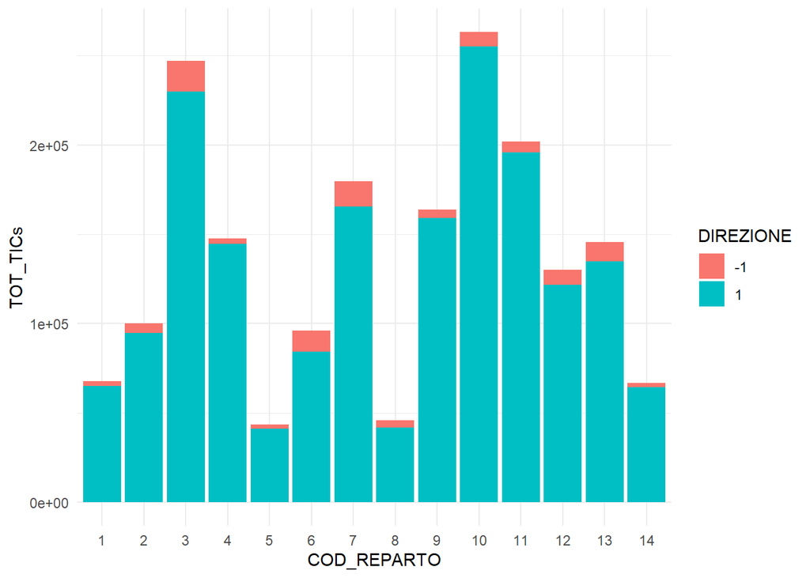

```r
#-- COD_REPARTO
ggplot(data = df7_dist_dep,
       aes(fill = DIREZIONE,
           x = COD_REPARTO,
           y = TOT_TICs)) +
  geom_bar(stat = "identity") +
  theme_minimal()
```

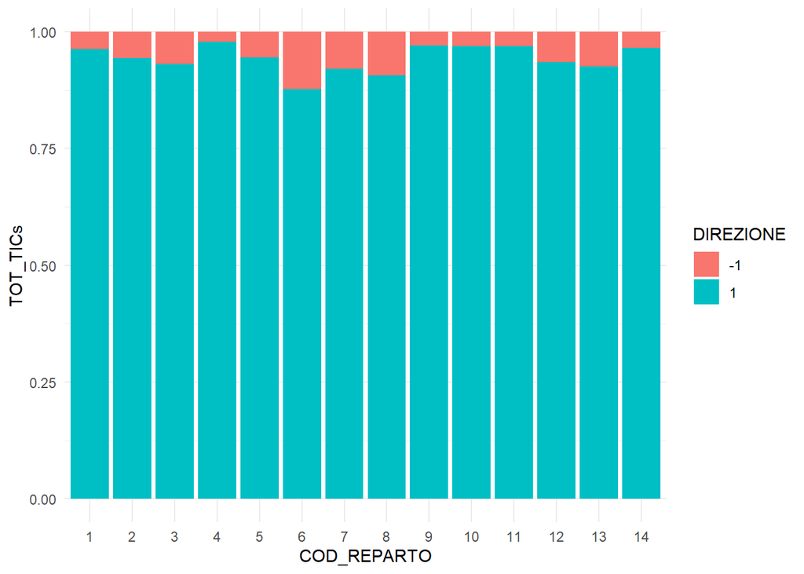

```r
#-- COD_REPARTO Percent
ggplot(data = df7_dist_dep,
       aes(fill = DIREZIONE,
           x = COD_REPARTO,
           y = TOT_TICs)) +
  geom_bar(stat = "identity",
           position = "fill" ) +
  theme_minimal()
```

Let’s take a general overiew about the `TIC_DATE_TYP` variable:

```r
df7_dist_datetyp <- tickets_clean %>%
  group_by(TIC_DATE_TYP, DIREZIONE) %>%
  summarize(TOT_TICs = n_distinct(ID_SCONTRINO),
            TOT_CLIs = n_distinct(ID_CLI)) %>%
  left_join(df7_dist_direction %>%
              select(DIREZIONE,
                     ALL_TOT_TICs = TOT_TICs,
                     ALL_TOT_CLIs = TOT_CLIs),
            by = 'DIREZIONE') %>%
  mutate(PERCENT_TICs = TOT_TICs/ALL_TOT_TICs,
         PERCENT_CLIs = TOT_CLIs/ALL_TOT_CLIs) %>%
  select(-ALL_TOT_TICs, -ALL_TOT_CLIs)

knitr::kable(df7_dist_datetyp)
```

| TIC_DATE_TYP | DIREZIONE | TOT_TICs | TOT_CLIs | PERCENT_TICs | PERCENT_CLIs |
| --- | --- | --- | --- | --- | --- |
| holiday | -1 | 14522 | 10759 | 0.1610174 | 0.2307709 |
| holiday | 1 | 157868 | 81742 | 0.1738929 | 0.3853501 |
| weekday | -1 | 47294 | 28981 | 0.5243877 | 0.6216164 |
| weekday | 1 | 452679 | 153338 | 0.4986297 | 0.7228696 |
| weekend | -1 | 28373 | 19565 | 0.3145949 | 0.4196517 |
| weekend | 1 | 297299 | 125137 | 0.3274773 | 0.5899238 |

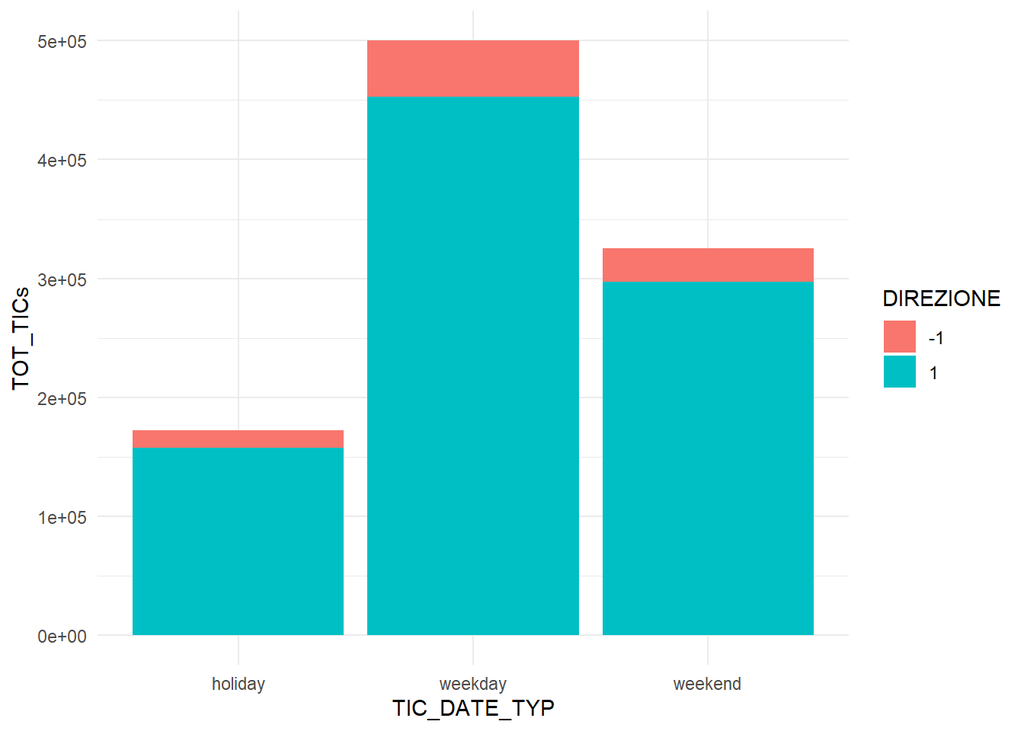

```r
#-- TIC_DATE_TYP
ggplot(data = df7_dist_datetyp,
       aes(fill = DIREZIONE,
           x = TIC_DATE_TYP,
           y = TOT_TICs)) +
 geom_bar(stat = "identity") +
 theme_minimal()
```

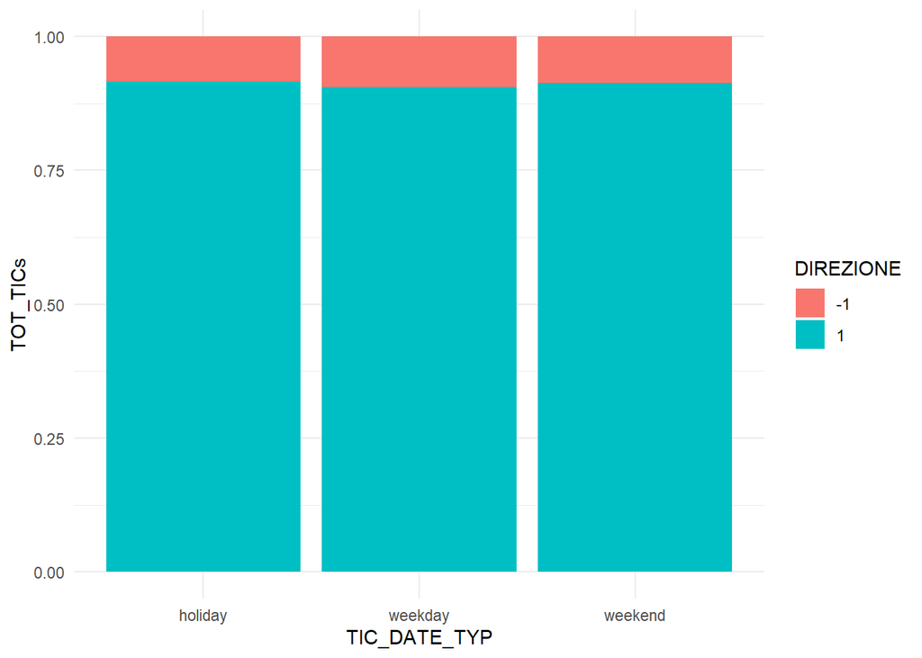

```r
#-- TIC_DATE_TYP Percent
ggplot(data = df7_dist_datetyp,
       aes(fill = DIREZIONE,
           x = TIC_DATE_TYP,
           y = TOT_TICs)) +
  geom_bar(stat = "identity",
           position = "fill" ) +
  theme_minimal()
```

Let’s take a general overiew about the `IMPORTO_LORDO` variable:

```r
df7_dist_importosconto <- tickets_clean %>%
  group_by(ID_SCONTRINO, DIREZIONE) %>%
  summarize(IMPORTO_LORDO = sum(IMPORTO_LORDO),
            SCONTO = sum(SCONTO)) %>%
  ungroup() %>%
  as.data.frame()

df7_dist_avgimportosconto <- df7_dist_importosconto %>%
  group_by(DIREZIONE) %>%
  summarize(AVG_IMPORTO_LORDO = mean(IMPORTO_LORDO),
            AVG_SCONTO = mean(SCONTO))

knitr::kable(df7_dist_avgimportosconto)
```

| DIREZIONE | AVG_IMPORTO_LORDO | AVG_SCONTO |
| --- | --- | --- |
| -1 | -109.6312 | -8.290584 |
| 1 | 164.2222 | 11.758403 |

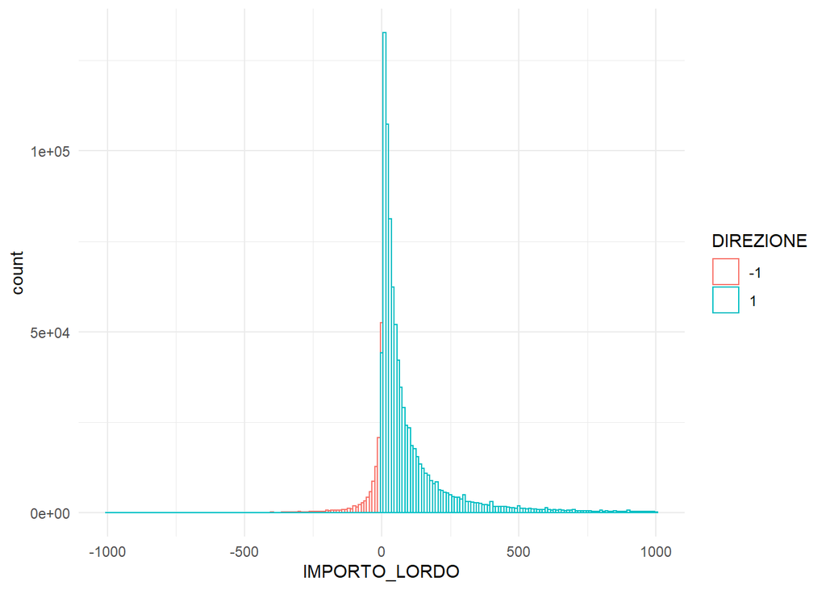

```r
#-- IMPORTO_LORDO
ggplot(data = df7_dist_importosconto %>%
         filter((IMPORTO_LORDO > -1000) & (IMPORTO_LORDO < 1000)),
       aes(color = DIREZIONE,
           x = IMPORTO_LORDO)) +
  geom_histogram(binwidth = 10,
                 fill = "white",
                 alpha = 0.5) +
  theme_minimal()
```

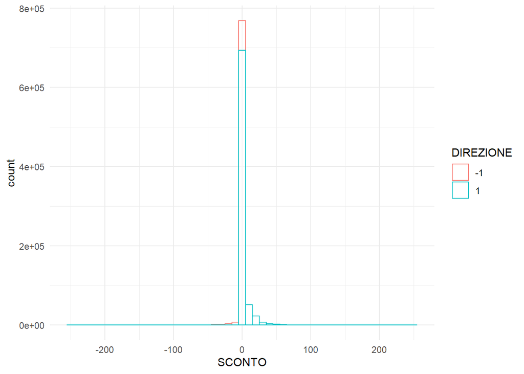

```r
#-- IMPORTO_LORDO Percent
ggplot(data = df7_dist_importosconto %>%
         filter((SCONTO > -250) & (IMPORTO_LORDO < 250)),
       aes(color = DIREZIONE, x = SCONTO)) +
  geom_histogram(binwidth = 10,
                 fill = "white",
                 alpha = 0.5) +
  theme_minimal()
```